# Интернет-магазин «Стримчик»

Предоставлены данные о продажах игр для разных платформ за период с 1980 до 2016 года по всему миру (отдельно выделены регионы: Северная Америка, Европа и Япония). Необходимо проанализировать данные и проверить некоторые гипотезы.

Цель исследования: Провести исследование данных чтобы выявить определяющие успешность игры закономерности. Это позволит сделать ставку на потенциально популярный продукт и спланировать рекламные кампании.

Ход исследования:

1. Выгрузить данные

2. Провести предобработку данных

2.1. Заменить названия столбцов

2.2. Преобразовать типы данных

2.3. Обработать пропуски

2.4. создать столбец с суммарными продажами по всем регионам

3. Провести исследовательский анализ данных

3.1. Какое количество игр выпускалось в разные годы?

3.2. Как менялись продажи по платформам с течением времени?

3.3. За какой характерный срок появляются новые и исчезают старые платформы?

3.4. Определить актуальный период для исследования

3.5. Какие платформы лидируют по продажам, растут или падают?

3.6. Построить график «ящик с усами» по глобальным продажам каждой игры и разбивкой по платформам

3.7. Выделяются ли жанры с высокими и низкими продажами?

4. Составить портрет пользователя для каждого исследуеиого региона

4.1. Определить самые популярные платформы (топ-5)

4.2. Определить самые популярные жанры (топ-5)

4.3. Определить самые популярные платформы (топ-5)

4.4. Влияет ли рейтинг ESRB на продажи в отдельном регионе?

4.5. Определить самые популярные игры в 2016 году (топ-5)

5. Проверить некоторые гипотезы

5.1. Средние пользовательские рейтинги платформ Xbox One и PC одинаковые

5.2. редние пользовательские рейтинги жанров Action (англ. «действие», экшен-игры) и Sports (англ. «спортивные соревнования») разные

6. Сделать общий вывод

```python
from scipy import stats as st
```

```python
import pandas as pd
```

```python
import matplotlib.pyplot as plt
```

```python
import seaborn as sns
```

```python
import numpy as np
```

## Загрузка данных.

К содержанию

```python
df = pd.read_csv('/datasets/games.csv')
```

```python
def load(df):
        print ('Первые 20 строк таблицы:')
        print ()
        display (df.head(20))
        print ()
        print ('Иноформация о таблице:')
        print ()
        display (df.info())
        print ()
        print ('Количество дубликатов в таблице:')
        print ()
        display (df.duplicated().sum())
        print ()
        print ('Количество пропусков в таблице:')
        print ()
        display (df.isna().sum())
        print ()
        print ('Процентное соотношение пропусков к общему числу значений для каждого столбца')
        print ()
        display (pd.DataFrame(round(df.isna().mean()*100,)).style.background_gradient('coolwarm'))
```

### Выведем первые 20 строк таблицы. Изучим общую информацию о датафрейме.

```python
load(df)
```

```
Первые 20 строк таблицы:
```

|  | Name | Platform | Year_of_Release | Genre | NA_sales | EU_sales | JP_sales | Other_sales | Critic_Score | User_Score | Rating |
| --- | --- | --- | --- | --- | --- | --- | --- | --- | --- | --- | --- |
| 0 | Wii Sports | Wii | 2006.0 | Sports | 41.36 | 28.96 | 3.77 | 8.45 | 76.0 | 8 | E |
| 1 | Super Mario Bros. | NES | 1985.0 | Platform | 29.08 | 3.58 | 6.81 | 0.77 | NaN | NaN | NaN |
| 2 | Mario Kart Wii | Wii | 2008.0 | Racing | 15.68 | 12.76 | 3.79 | 3.29 | 82.0 | 8.3 | E |
| 3 | Wii Sports Resort | Wii | 2009.0 | Sports | 15.61 | 10.93 | 3.28 | 2.95 | 80.0 | 8 | E |
| 4 | Pokemon Red/Pokemon Blue | GB | 1996.0 | Role-Playing | 11.27 | 8.89 | 10.22 | 1.00 | NaN | NaN | NaN |
| 5 | Tetris | GB | 1989.0 | Puzzle | 23.20 | 2.26 | 4.22 | 0.58 | NaN | NaN | NaN |
| 6 | New Super Mario Bros. | DS | 2006.0 | Platform | 11.28 | 9.14 | 6.50 | 2.88 | 89.0 | 8.5 | E |
| 7 | Wii Play | Wii | 2006.0 | Misc | 13.96 | 9.18 | 2.93 | 2.84 | 58.0 | 6.6 | E |
| 8 | New Super Mario Bros. Wii | Wii | 2009.0 | Platform | 14.44 | 6.94 | 4.70 | 2.24 | 87.0 | 8.4 | E |
| 9 | Duck Hunt | NES | 1984.0 | Shooter | 26.93 | 0.63 | 0.28 | 0.47 | NaN | NaN | NaN |
| 10 | Nintendogs | DS | 2005.0 | Simulation | 9.05 | 10.95 | 1.93 | 2.74 | NaN | NaN | NaN |
| 11 | Mario Kart DS | DS | 2005.0 | Racing | 9.71 | 7.47 | 4.13 | 1.90 | 91.0 | 8.6 | E |
| 12 | Pokemon Gold/Pokemon Silver | GB | 1999.0 | Role-Playing | 9.00 | 6.18 | 7.20 | 0.71 | NaN | NaN | NaN |
| 13 | Wii Fit | Wii | 2007.0 | Sports | 8.92 | 8.03 | 3.60 | 2.15 | 80.0 | 7.7 | E |
| 14 | Kinect Adventures! | X360 | 2010.0 | Misc | 15.00 | 4.89 | 0.24 | 1.69 | 61.0 | 6.3 | E |
| 15 | Wii Fit Plus | Wii | 2009.0 | Sports | 9.01 | 8.49 | 2.53 | 1.77 | 80.0 | 7.4 | E |
| 16 | Grand Theft Auto V | PS3 | 2013.0 | Action | 7.02 | 9.09 | 0.98 | 3.96 | 97.0 | 8.2 | M |
| 17 | Grand Theft Auto: San Andreas | PS2 | 2004.0 | Action | 9.43 | 0.40 | 0.41 | 10.57 | 95.0 | 9 | M |
| 18 | Super Mario World | SNES | 1990.0 | Platform | 12.78 | 3.75 | 3.54 | 0.55 | NaN | NaN | NaN |
| 19 | Brain Age: Train Your Brain in Minutes a Day | DS | 2005.0 | Misc | 4.74 | 9.20 | 4.16 | 2.04 | 77.0 | 7.9 | E |

```
Иноформация о таблице:

<class 'pandas.core.frame.DataFrame'>
RangeIndex: 16715 entries, 0 to 16714
Data columns (total 11 columns):
 #   Column           Non-Null Count  Dtype
---  ------           --------------  -----
 0   Name             16713 non-null  object
 1   Platform         16715 non-null  object
 2   Year_of_Release  16446 non-null  float64
 3   Genre            16713 non-null  object
 4   NA_sales         16715 non-null  float64
 5   EU_sales         16715 non-null  float64
 6   JP_sales         16715 non-null  float64
 7   Other_sales      16715 non-null  float64
 8   Critic_Score     8137 non-null   float64
 9   User_Score       10014 non-null  object
 10  Rating           9949 non-null   object
dtypes: float64(6), object(5)
memory usage: 1.4+ MB
```

```
None
```

```
Количество дубликатов в таблице:
```

```
0
```

```
Количество пропусков в таблице:
```

```
Name                  2
Platform              0
Year_of_Release     269
Genre                 2
NA_sales              0
EU_sales              0
JP_sales              0
Other_sales           0
Critic_Score       8578
User_Score         6701
Rating             6766
dtype: int64
```

```
Процентное соотношение пропусков к общему числу значений для каждого столбца
```

|  | 0 |
| --- | --- |
| Name | 0.000000 |
| Platform | 0.000000 |
| Year_of_Release | 2.000000 |
| Genre | 0.000000 |
| NA_sales | 0.000000 |
| EU_sales | 0.000000 |
| JP_sales | 0.000000 |
| Other_sales | 0.000000 |
| Critic_Score | 51.000000 |
| User_Score | 40.000000 |
| Rating | 40.000000 |

### Вывод:

Таблица содержит исторические данные о продажах игр, оценки пользователей и экспертов, жанры и платформы и состоит из 11 столбцов:

**Name** — название игры

**Platform** — платформа

**Year_of_Release** — год выпуска

**Genre** — жанр игры

**NA_sales** — продажи в Северной Америке (миллионы проданных копий)

**EU_sales** — продажи в Европе (миллионы проданных копий)

**JP_sales** — продажи в Японии (миллионы проданных копий)

**Other_sales** — продажи в других странах (миллионы проданных копий)

**Critic_Score** — оценка критиков (максимум 100)

**User_Score** — оценка пользователей (максимум 10)

**Rating** — рейтинг от организации ESRB (англ. Entertainment Software Rating Board). Эта ассоциация определяет рейтинг компьютерных игр и присваивает им подходящую возрастную категорию.

В таблице присутствуют строковые и числовые значения, есть пропуски в столбцах с названем игры, годом выпуска (пропущено 2% данных), оценкой критиков (51%), оценкой пользователей (40%) и рейтингом от организации ESRB (40%), дубликатов в таблице нет.

## Предобработка данных.

К содержанию

### Приведём названия столбцов к нижнему регистру.

```python
df.columns = df.columns.str.lower()
```

### Обработаем пропуски.

#### Пропусков в столбце с названием игр всего два, можно удалить эти строки, эото не повлияет на репрезантативность выборки.

```python
df = df.dropna(subset=['name'])
```

Пропуски могли возникнуть из-за ошибки сборщика данных или по техническимс причинам.

#### Пропусков в столбце с годом выпуска игр всего 2 %, можно удалить эти строки, эото не повлияет на репрезантативность выборки.

```python
df = df.dropna(subset=['year_of_release'])
```

Пропуски могли возникнуть из-за ошибки сборщика данных или по техническимс причинам.

#### Пропусков в столбце с жанром игр всего два, можно удалить эти строки, это не повлияет на репрезантативность выборки.

```python
df = df.dropna(subset=['genre'])
```

Пропуски могли возникнуть из-за ошибки сборщика данных или по техническимс причинам.

#### Пропусков в столбце с оценкой критиков 51%, удалить их не получится, поэтому заменим пропуски на 0.

```python
df['critic_score'] = df['critic_score'].fillna(0)
```

Возможно для этих игр не удалось найти оценки критиков, либо это новые игры и оценки еще не проставлены.

#### Пропусков в столбце с оценкой пользователей 40%, удалить их не получится, поэтому заменим пропуски на 0.

```python
df['user_score'] = df['user_score'].fillna(0)
```

Возможно для этих игр не удалось найти оценки пользователей, либо это новые игры и оценки еще не проставлены.

#### Также в столбце с оценкой пользователей есть значения 'tbd', их тоже заменим на 0.

```python
df.loc[df['user_score'] == 'tbd', 'user_score'] = 0
```

Возможно этим играм еще не присвоен рейтинг.

#### Пропусков в столбце с рейтингом от организации ESRB 40%, удалить их не получится, поэтому заменим пропуски на 'unknown'.

```python
df['rating'] = df['rating'].fillna('unknown')
```

### Преобразуем данные в нужные типы.

#### Тип столбца с данными о названии платформы можно заменить со строкового на категориальный, так как они занимают меньше памяти.

```python
df['platform'].unique()
```

```
array(['Wii', 'NES', 'GB', 'DS', 'X360', 'PS3', 'PS2', 'SNES', 'GBA',
       'PS4', '3DS', 'N64', 'PS', 'XB', 'PC', '2600', 'PSP', 'XOne',
       'WiiU', 'GC', 'GEN', 'DC', 'PSV', 'SAT', 'SCD', 'WS', 'NG', 'TG16',
       '3DO', 'GG', 'PCFX'], dtype=object)
```

#### Тип столбца с данными о годе выпуска можно заменить с вещественного на целочисленный, так как они занимают меньше памяти.

```python
df['year_of_release'] = df['year_of_release'].astype('int16', errors='ignore')
```

#### Тип столбца с данными о жанре можно заменить со строкового на категориальный, так как они занимают меньше памяти.

```python
df['genre'].unique()
```

```
array(['Sports', 'Platform', 'Racing', 'Role-Playing', 'Puzzle', 'Misc',
       'Shooter', 'Simulation', 'Action', 'Fighting', 'Adventure',
       'Strategy'], dtype=object)
```

#### Тип столбца с данными об оценки пользователей можно заменить с строкового на вещественный, так как они занимают меньше памяти.

```python
df['user_score'].unique()
```

```
array(['8', 0, '8.3', '8.5', '6.6', '8.4', '8.6', '7.7', '6.3', '7.4',
       '8.2', '9', '7.9', '8.1', '8.7', '7.1', '3.4', '5.3', '4.8', '3.2',
       '8.9', '6.4', '7.8', '7.5', '2.6', '7.2', '9.2', '7', '7.3', '4.3',
       '7.6', '5.7', '5', '9.1', '6.5', '8.8', '6.9', '9.4', '6.8', '6.1',
       '6.7', '5.4', '4', '4.9', '4.5', '9.3', '6.2', '4.2', '6', '3.7',
       '4.1', '5.8', '5.6', '5.5', '4.4', '4.6', '5.9', '3.9', '3.1',
       '2.9', '5.2', '3.3', '4.7', '5.1', '3.5', '2.5', '1.9', '3', '2.7',
       '2.2', '2', '9.5', '2.1', '3.6', '2.8', '1.8', '3.8', '0', '1.6',
       '9.6', '2.4', '1.7', '1.1', '0.3', '1.5', '0.7', '1.2', '2.3',
       '0.5', '1.3', '0.2', '0.6', '1.4', '0.9', '1', '9.7'], dtype=object)
```

```python
df['user_score'] = df['user_score'].astype('float')
```

'tbd'(to be determined = будет определено)

#### Тип столбца с данными об оценки критиков можно заменить с вещественного на целочисленный, так как они занимают меньше памяти.

```python
df['critic_score'].unique()
```

```
array([76.,  0., 82., 80., 89., 58., 87., 91., 61., 97., 95., 77., 88.,
       83., 94., 93., 85., 86., 98., 96., 90., 84., 73., 74., 78., 92.,
       71., 72., 68., 62., 49., 67., 81., 66., 56., 79., 70., 59., 64.,
       75., 60., 63., 69., 50., 25., 42., 44., 55., 48., 57., 29., 47.,
       65., 54., 20., 53., 37., 38., 33., 52., 30., 32., 43., 45., 51.,
       40., 46., 39., 34., 41., 36., 31., 27., 35., 26., 19., 28., 23.,
       24., 21., 17., 13.])
```

```python
df['critic_score'] = df['critic_score'].astype('int8')
```

#### Тип столбца с данными о рейтинге от организации ESRB можно заменить со строкового на категориальный, так как они занимают меньше памяти.

```python
df['rating'].unique()
```

```
array(['E', 'unknown', 'M', 'T', 'E10+', 'K-A', 'AO', 'EC', 'RP'],
      dtype=object)
```

### Посчитаем суммарные продажи во всех регионах и запишем их в отдельный столбец.

```python
df['all_sales'] = df[['na_sales', 'eu_sales', 'jp_sales', 'other_sales']].sum(axis=1)
```

```python
load(df)
```

```
Первые 20 строк таблицы:
```

|  | name | platform | year_of_release | genre | na_sales | eu_sales | jp_sales | other_sales | critic_score | user_score | rating | all_sales |
| --- | --- | --- | --- | --- | --- | --- | --- | --- | --- | --- | --- | --- |
| 0 | Wii Sports | Wii | 2006 | Sports | 41.36 | 28.96 | 3.77 | 8.45 | 76 | 8.0 | E | 82.54 |
| 1 | Super Mario Bros. | NES | 1985 | Platform | 29.08 | 3.58 | 6.81 | 0.77 | 0 | 0.0 | unknown | 40.24 |
| 2 | Mario Kart Wii | Wii | 2008 | Racing | 15.68 | 12.76 | 3.79 | 3.29 | 82 | 8.3 | E | 35.52 |
| 3 | Wii Sports Resort | Wii | 2009 | Sports | 15.61 | 10.93 | 3.28 | 2.95 | 80 | 8.0 | E | 32.77 |
| 4 | Pokemon Red/Pokemon Blue | GB | 1996 | Role-Playing | 11.27 | 8.89 | 10.22 | 1.00 | 0 | 0.0 | unknown | 31.38 |
| 5 | Tetris | GB | 1989 | Puzzle | 23.20 | 2.26 | 4.22 | 0.58 | 0 | 0.0 | unknown | 30.26 |
| 6 | New Super Mario Bros. | DS | 2006 | Platform | 11.28 | 9.14 | 6.50 | 2.88 | 89 | 8.5 | E | 29.80 |
| 7 | Wii Play | Wii | 2006 | Misc | 13.96 | 9.18 | 2.93 | 2.84 | 58 | 6.6 | E | 28.91 |
| 8 | New Super Mario Bros. Wii | Wii | 2009 | Platform | 14.44 | 6.94 | 4.70 | 2.24 | 87 | 8.4 | E | 28.32 |
| 9 | Duck Hunt | NES | 1984 | Shooter | 26.93 | 0.63 | 0.28 | 0.47 | 0 | 0.0 | unknown | 28.31 |
| 10 | Nintendogs | DS | 2005 | Simulation | 9.05 | 10.95 | 1.93 | 2.74 | 0 | 0.0 | unknown | 24.67 |
| 11 | Mario Kart DS | DS | 2005 | Racing | 9.71 | 7.47 | 4.13 | 1.90 | 91 | 8.6 | E | 23.21 |
| 12 | Pokemon Gold/Pokemon Silver | GB | 1999 | Role-Playing | 9.00 | 6.18 | 7.20 | 0.71 | 0 | 0.0 | unknown | 23.09 |
| 13 | Wii Fit | Wii | 2007 | Sports | 8.92 | 8.03 | 3.60 | 2.15 | 80 | 7.7 | E | 22.70 |
| 14 | Kinect Adventures! | X360 | 2010 | Misc | 15.00 | 4.89 | 0.24 | 1.69 | 61 | 6.3 | E | 21.82 |
| 15 | Wii Fit Plus | Wii | 2009 | Sports | 9.01 | 8.49 | 2.53 | 1.77 | 80 | 7.4 | E | 21.80 |
| 16 | Grand Theft Auto V | PS3 | 2013 | Action | 7.02 | 9.09 | 0.98 | 3.96 | 97 | 8.2 | M | 21.05 |
| 17 | Grand Theft Auto: San Andreas | PS2 | 2004 | Action | 9.43 | 0.40 | 0.41 | 10.57 | 95 | 9.0 | M | 20.81 |
| 18 | Super Mario World | SNES | 1990 | Platform | 12.78 | 3.75 | 3.54 | 0.55 | 0 | 0.0 | unknown | 20.62 |
| 19 | Brain Age: Train Your Brain in Minutes a Day | DS | 2005 | Misc | 4.74 | 9.20 | 4.16 | 2.04 | 77 | 7.9 | E | 20.14 |

```
Иноформация о таблице:

<class 'pandas.core.frame.DataFrame'>
Int64Index: 16444 entries, 0 to 16714
Data columns (total 12 columns):
 #   Column           Non-Null Count  Dtype
---  ------           --------------  -----
 0   name             16444 non-null  object
 1   platform         16444 non-null  object
 2   year_of_release  16444 non-null  int16
 3   genre            16444 non-null  object
 4   na_sales         16444 non-null  float64
 5   eu_sales         16444 non-null  float64
 6   jp_sales         16444 non-null  float64
 7   other_sales      16444 non-null  float64
 8   critic_score     16444 non-null  int8
 9   user_score       16444 non-null  float64
 10  rating           16444 non-null  object
 11  all_sales        16444 non-null  float64
dtypes: float64(6), int16(1), int8(1), object(4)
memory usage: 1.4+ MB
```

```
None
```

```
Количество дубликатов в таблице:
```

```
0
```

```
Количество пропусков в таблице:
```

```
name               0
platform           0
year_of_release    0
genre              0
na_sales           0
eu_sales           0
jp_sales           0
other_sales        0
critic_score       0
user_score         0
rating             0
all_sales          0
dtype: int64
```

```
Процентное соотношение пропусков к общему числу значений для каждого столбца
```

|  | 0 |
| --- | --- |
| name | 0.000000 |
| platform | 0.000000 |
| year_of_release | 0.000000 |
| genre | 0.000000 |
| na_sales | 0.000000 |
| eu_sales | 0.000000 |
| jp_sales | 0.000000 |
| other_sales | 0.000000 |
| critic_score | 0.000000 |
| user_score | 0.000000 |
| rating | 0.000000 |
| all_sales | 0.000000 |

### Вывод:

На этапе предобработки данных все названия столбцов были приведены к нижнему регистру.

Были обработаны пропуски.

Строки с пропусками в названии игр, годе выпуска и жанре были удалены, так как не несли полезной информации и их количество было небольшим, поэтому их удаление не повлияло на репрезантивность выборки.

Строки с пропусками в оценке пользователей и оценке критиков удалить нельзя, так как их количество очень велико, пропуски и значения "tbd" были заменены на индикаторное значение - 0, так как рейтинг узнать нет возможности, а заполнение любым рассчетным значением исказит реальные данные.

Строки с пропусками в рейтинге от организации ESRB, так же нельзя удалить, и заполнить рассчетным значением, поээтому они были заполнены индикаторным значением "unknown".

Данные были преобразованы в нужные типы.

Данные о годе выпуска и оценке критиков можно заменить на целочисленный, так как в них нет дробных частей.

Пропуски в данных могут быть обусловлены техническими или человеческими факторами, некоторые данные могут отсутствовать для недавно вышедших или очень старых игр.

Данные об оценке пользователей удалось изменить с объектного типа на числовой, благодаря тому что значение "tbd" было заменено на 0, это упростит дальнейшую работу и значительно сократит использование памяти.

В таблицу был добавлен новый столбец "all_sales" содержащий суммарные объемы продаж во всех исследуемых регионах (в миллионах проданных копий).

## Исследовательский анализ данных.

К содержанию

### Посмотрим сколько игр выпускалось в разные годы.

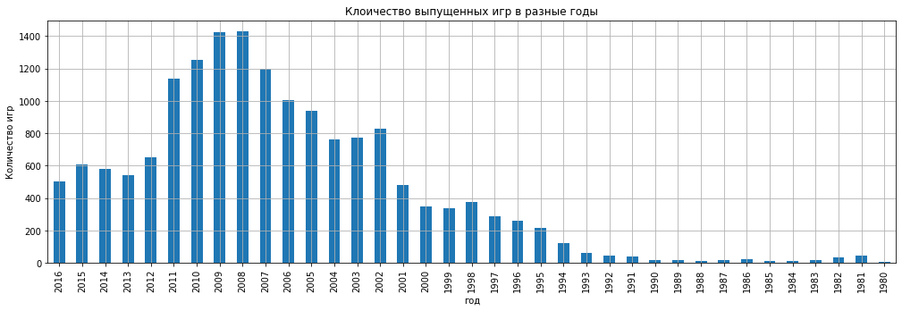

```python
df.pivot_table(
    index='year_of_release',
    values='name',
    aggfunc='count').sort_values(
    by='year_of_release',
    ascending=False).plot(
    kind='bar',
    figsize=(17,5),
    ylabel='Количество игр',
    xlabel='год',
    title='Клоичество выпущенных игр в разные годы',
    grid=True,
    legend=False);
```

Больше всего игр вышло в период с 2005 по 2011 года, пик пришелся на 2008-2009 год. Эти данные пригодятся, когла мы будем рассматривать продажи для каждой отдельно й платформы по годам.

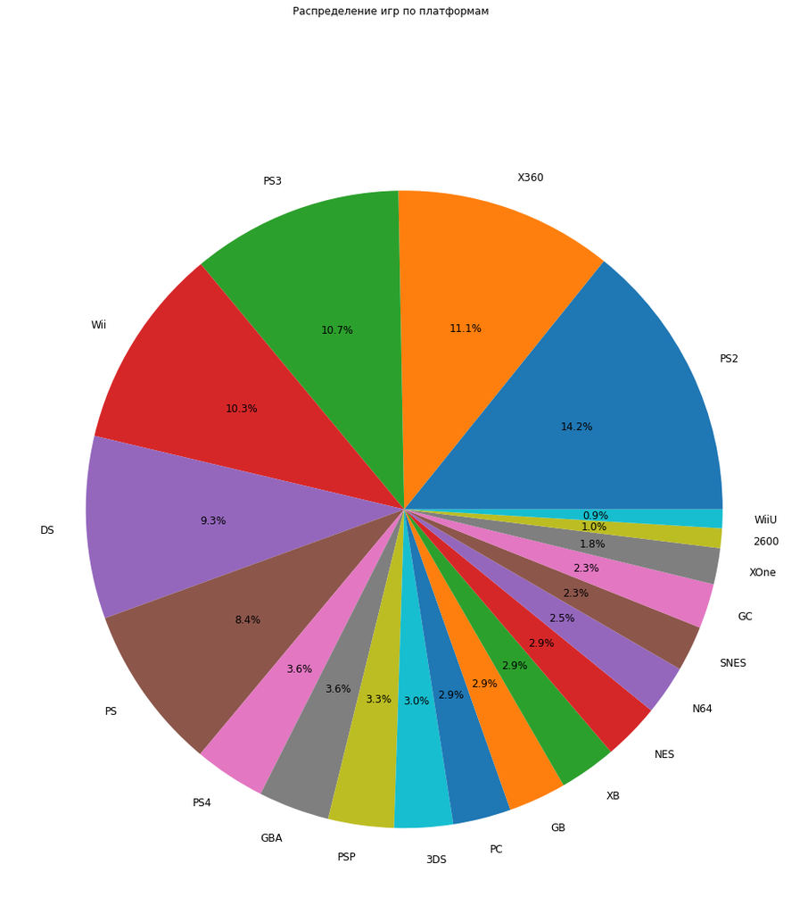

```python
df.pivot_table(
    index='platform',
    values='all_sales',
    aggfunc='sum').sort_values(
    by='all_sales',
    ascending=False).head(20).plot(
   kind='pie',
    subplots=True,
    autopct ='%1.1f%%',
    legend=False,
    figsize=(17,17),
    fontsize=12,
    ylabel='',
    xlabel='',
    title='Распределение игр по платформам');
```

На графике распределение по продажам для 20 платформ. За всё время наблюдений самые большие продажи у платформы PS2, далее идут X360, PS3, Wii, DS, PS, PS4 и так далее.

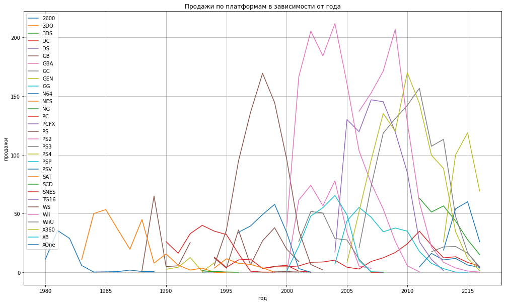

```python
df.pivot_table(index='year_of_release', columns='platform', values='all_sales', aggfunc='sum').plot(figsize=(17,10))
plt.title('Продажи по платформам в зависимости от года')
plt.xlabel('год')
plt.ylabel('продажи')
plt.grid(True)
plt.legend(loc=2)
plt.show()
```

### Рассмотрим, как менялись продажи по платформам.

#### Рассмотрим средний срок популярности платформ.

```python
df.loc[
    :,['year_of_release', 'platform']
].drop_duplicates(
).pivot_table(
    index='platform',
    values='year_of_release',
    aggfunc='count').sort_values(
    by='year_of_release',
    ascending=False)
```

| platform | year_of_release |
| --- | --- |
| PC | 26 |
| GB | 13 |
| NES | 12 |
| X360 | 12 |
| PSP | 12 |
| PS2 | 12 |
| Wii | 11 |
| DS | 11 |
| PS3 | 11 |
| 2600 | 10 |
| SNES | 10 |
| PS | 10 |
| XB | 9 |
| GBA | 8 |
| DC | 7 |
| GC | 7 |
| N64 | 7 |
| SAT | 6 |
| 3DS | 6 |
| PSV | 6 |
| WiiU | 5 |
| GEN | 5 |
| NG | 4 |
| PS4 | 4 |
| XOne | 4 |
| WS | 3 |
| SCD | 2 |
| 3DO | 2 |
| TG16 | 1 |
| GG | 1 |
| PCFX | 1 |

```python
df.loc[
    :,['year_of_release', 'platform']
].drop_duplicates(
).pivot_table(
    index=['platform'],
    values='year_of_release',
    aggfunc='count').describe()
```

|  | year_of_release |
| --- | --- |
| count | 31.000000 |
| mean | 7.677419 |
| std | 5.081910 |
| min | 1.000000 |
| 25% | 4.000000 |
| 50% | 7.000000 |
| 75% | 11.000000 |
| max | 26.000000 |

В среднем платформа "живёт" 7 лет, примерно половину времени платформа растет, а вторую половину - падает, поэтому примем за актуальный период 3 года. PC - платформа долгожитель (26 лет).

### Посмотрим, какие платформы лидируют по продажам, растут или падают.

#### Рассмотрим популярные платформы начиная с 2014 года.

```python
df_2014 = df.query('year_of_release >= 2014')
```

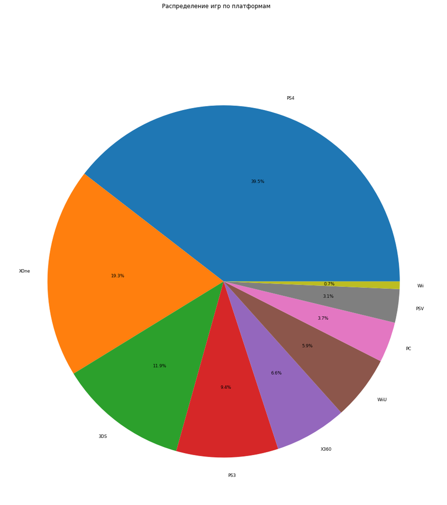

```python
df_2014.pivot_table(
    index='platform',
    values='all_sales',
    aggfunc='sum').sort_values(
    by='all_sales',
    ascending=False).query(
    'all_sales > 0').head(9).plot(
    kind='pie',
    subplots=True,
    autopct ='%1.1f%%',
    legend=False,
    figsize=(17,17),
    fontsize=9,
    ylabel='',
    title='Распределение игр по платформам');
```

```python
df_2014.pivot_table(
    index='platform',
    values = 'all_sales',
    aggfunc='sum').query(
    'all_sales > 0').sort_values(
    by='all_sales',
    ascending=False)
```

| platform | all_sales |
| --- | --- |
| PS4 | 288.15 |
| XOne | 140.36 |
| 3DS | 86.68 |
| PS3 | 68.18 |
| X360 | 48.22 |
| WiiU | 42.98 |
| PC | 27.05 |
| PSV | 22.40 |
| Wii | 5.07 |
| PSP | 0.36 |

За последние 3 года самыми популярными платформами являются PS4, XOne и 3DS.

#### Теперь рассмотрим изменения в продажах для каждой платформы отдельно.

```python
def bar (df, title, xlabel, ylabel):
    df.pivot_table(
    index='year_of_release',
    values='all_sales',
    aggfunc='sum').sort_values(
    by='year_of_release',
    ascending=False).plot(
    kind='bar',
    figsize=(17,5),
    ylabel=ylabel,
    xlabel=xlabel,
    title=title,
    grid=True,
    legend=False);
```

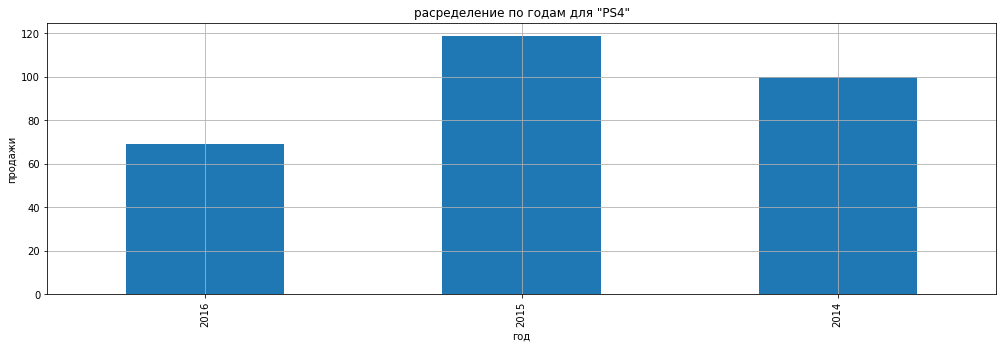

```python
bar(df_2014.query('platform == "PS4"'), 'расределение по годам для "PS4"', 'год', 'продажи')
```

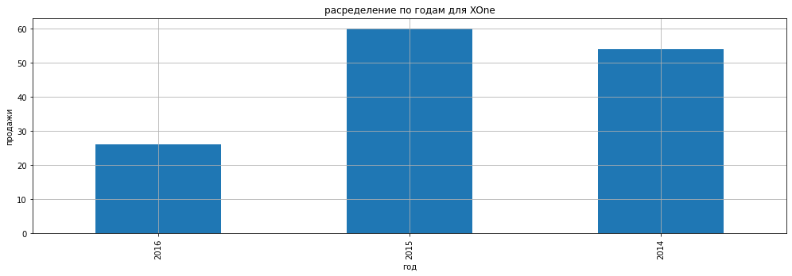

```python
bar(df_2014.query('platform == "XOne"'), 'расределение по годам для XOne', 'год', 'продажи')
```

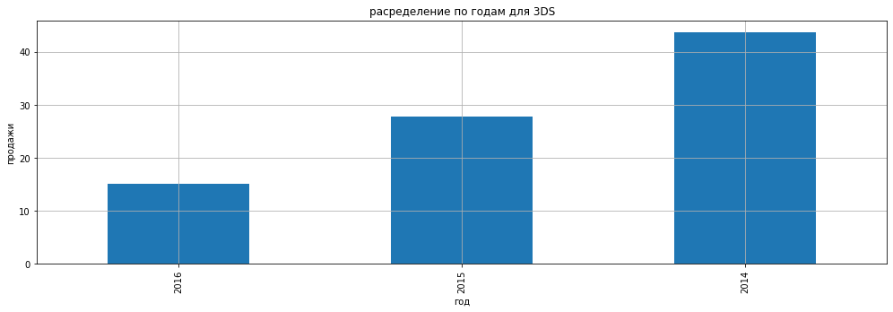

```python
bar(df_2014.query('platform == "3DS"'), 'расределение по годам для 3DS', 'год', 'продажи')
```

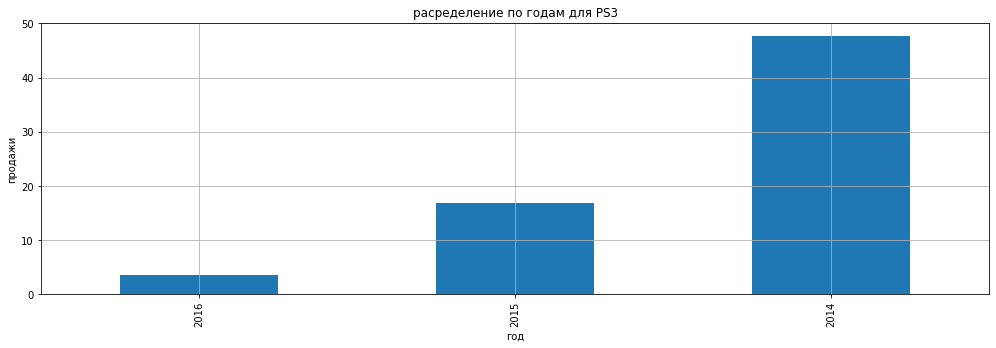

```python
bar(df_2014.query('platform == "PS3"'), 'расределение по годам для PS3', 'год', 'продажи')
```

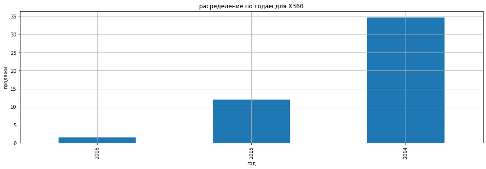

```python
bar(df_2014.query('platform == "X360"'), 'расределение по годам для X360', 'год', 'продажи')
```

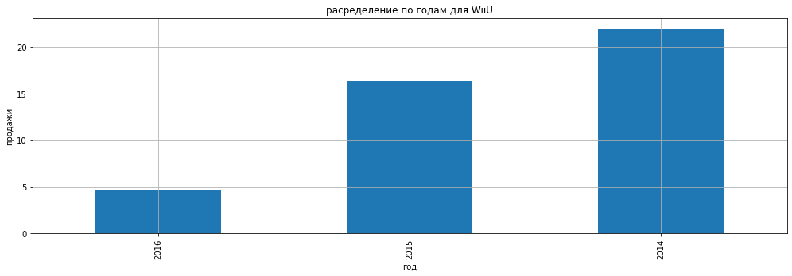

```python
bar(df_2014.query('platform == "WiiU"'), 'расределение по годам для WiiU', 'год', 'продажи')
```

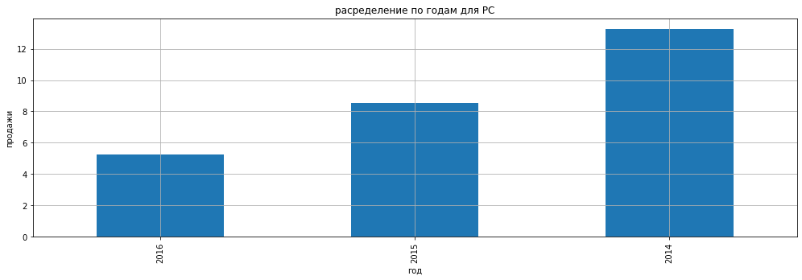

```python
bar(df_2014.query('platform == "PC"'), 'расределение по годам для PC', 'год', 'продажи')
```

#### Визуализируем распределение продаж за последние 3 года на разных платформах.

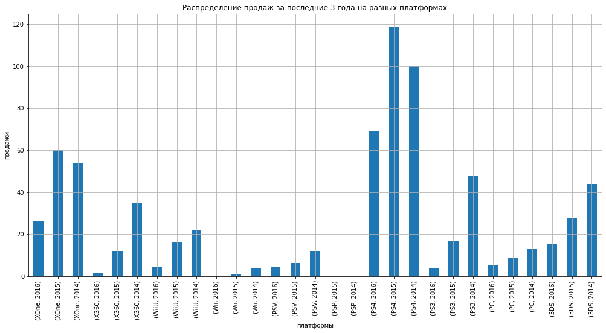

```python
df_2014.pivot_table(
    index=['platform', 'year_of_release'],
    values='all_sales',
    aggfunc='sum').sort_values(
    by=['platform', 'year_of_release'],
    ascending=False).plot(
    kind='bar',
    figsize=(17,8),
    ylabel='продажи',
    xlabel='платформы',
    title='Распределение продаж за последние 3 года на разных платформах',
    grid=True,
    legend=False);
```

Неплохо себя показывают PS4, XOne и 3DS. Хотя и там заметно снижение продаж. Так же снижаются продажи игр для PC, однако эта платформа по представленным данным существует уже 26 лет, так что игры для пк будут выходить и дальше.

### Построим график «ящик с усами» по глобальным продажам игр в разбивке по платформам.

```python
df_2014 = df[df['year_of_release']>= 2014]
```

```
count    1689.000000
mean        0.431883
std         1.056109
min         0.010000
25%         0.030000
50%         0.100000
75%         0.350000
max        14.630000
Name: all_sales, dtype: float64
```

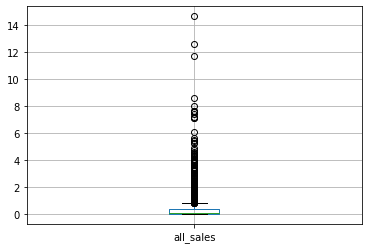

```python
df_2014.boxplot(column = 'all_sales')
df_2014['all_sales'].describe()
```

```
count    376.000000
mean       0.766356
std        1.614969
min        0.010000
25%        0.057500
50%        0.185000
75%        0.690000
max       14.630000
Name: all_sales, dtype: float64
```

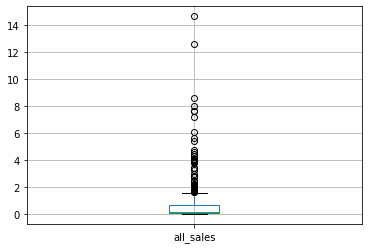

```python
PS4_2014 = df_2014.query('platform =="PS4"')
PS4_2014.boxplot(column = 'all_sales')

PS4_2014['all_sales'].describe()
```

```
count    228.000000
mean       0.615614
std        1.046513
min        0.010000
25%        0.050000
50%        0.205000
75%        0.632500
max        7.390000
Name: all_sales, dtype: float64
```

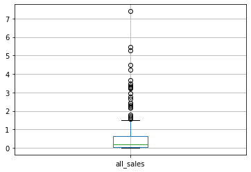

```python
XOne_2014 = df_2014.query('platform =="XOne"')
XOne_2014.boxplot(column = 'all_sales')
XOne_2014['all_sales'].describe()
```

```
count    212.000000
mean       0.408868
std        1.188368
min        0.010000
25%        0.030000
50%        0.090000
75%        0.250000
max       11.680000
Name: all_sales, dtype: float64
```

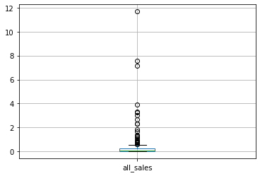

```python
_3DS_2014 = df_2014.query('platform =="3DS"')
_3DS_2014.boxplot(column = 'all_sales')
_3DS_2014['all_sales'].describe()
```

```
count    150.000000
mean       0.160000
std        0.231349
min        0.010000
25%        0.020000
50%        0.060000
75%        0.200000
max        1.280000
Name: all_sales, dtype: float64
```

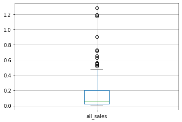

```python
PC_2014 = df_2014.loc[(df['platform'] =="PC")&(df['all_sales']<1.5)]
PC_2014.boxplot(column = 'all_sales')
PC_2014['all_sales'].describe()
```

Для разных платформ диаграммы размаха различаются. За период 2014-2016 год для каждой платформы были выпущены 1-3 игры с высокими продажами.

```python
list_of_top = ['PS4','XOne','3DS','PC']
```

```python
df_2014_top_platforms = df_2014.loc[(df_2014['platform'].isin(list_of_top))&(df_2014['all_sales']<3)]
```

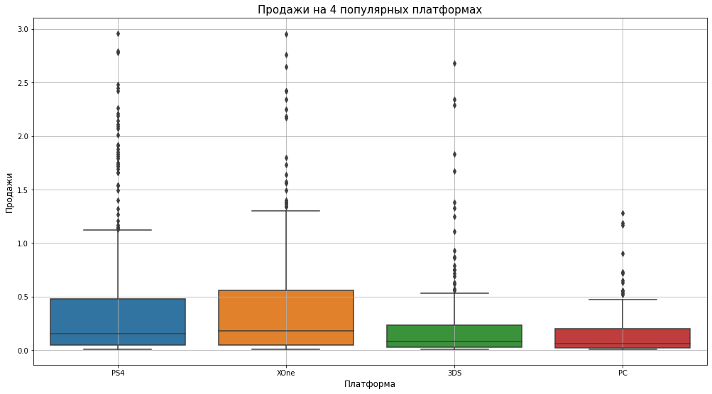

```python
plt.figure(figsize=(17,9))
sns.boxplot(data=df_2014_top_platforms, x='platform', y='all_sales')
plt.title('Продажи на 4 популярных платформах', fontsize=15)
plt.xlabel('Платформа', fontsize=12)
plt.ylabel('Продажи',fontsize=12)
plt.grid()
plt.show()
```

Для платформ 3DS и PC медианное значение, первый и третий квартили и нормальное распределение примерно одинаковые, однако у платформы 3DS больше выбросов сверху. Для платформ PS4 и XOne медианное значение и первый квартиль находятся примерно на одном уровне, но у Xone третий квартиль выше, как и нормальное распределение, при этом у PS4 больше выбросов сверху.

### Посмотрим, как влияют на продажи внутри одной популярной платформы отзывы пользователей и критиков.

#### Построим диаграмму рассеяния и посчитайте корреляцию между отзывами и продажами сначала глобально.

```python
def corr_scatter(df, x1label, x2label):
    print ('Зависимость продаж от отзывов пользователей')
    print()
    print (df['all_sales'].corr(df[x1label]))
    print()
    print('Диаграмма рассеяния')
    print()
    df.plot(y='all_sales', x=x1label, kind='scatter', alpha=0.9, grid=True)
    plt.show()
    print()
    print ('Зависимость продаж от отзывов критиков')
    print()
    print (df['all_sales'].corr(df[x2label]))
    print()
    print('Диаграмма рассеяния')
    print()
    df.plot(y='all_sales', x=x2label, kind='scatter', alpha=0.9, grid=True)
    plt.show()
    print ('Зависимость между отзывами пользователей и отзывами критиков')
    print()
    print (df[x1label].corr(df[x2label]))
    print()
    print('Диаграмма рассеяния')
    print()
    df.plot(y=x1label, x=x2label, kind='scatter', alpha=0.9, grid=True)
    plt.show()
```

```
Зависимость продаж от отзывов пользователей

0.08841546035831234

Диаграмма рассеяния
```

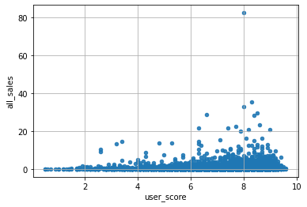

```
Зависимость продаж от отзывов критиков

0.23708664004781937

Диаграмма рассеяния
```

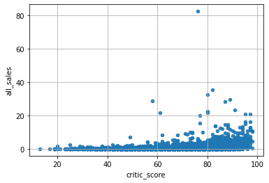

```
Зависимость между отзывами пользователей и отзывами критиков

0.579670628193222

Диаграмма рассеяния
```

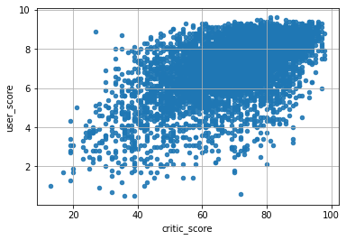

```python
corr_scatter(df.query('user_score > 0 and critic_score > 0'), 'user_score', 'critic_score')
```

```
Зависимость продаж от отзывов пользователей

0.005202258360087507

Диаграмма рассеяния
```

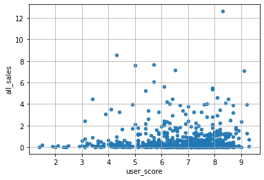

```
Зависимость продаж от отзывов критиков

0.3253626120075887

Диаграмма рассеяния
```

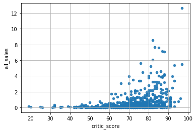

```
Зависимость между отзывами пользователей и отзывами критиков

0.5044604031800752

Диаграмма рассеяния
```

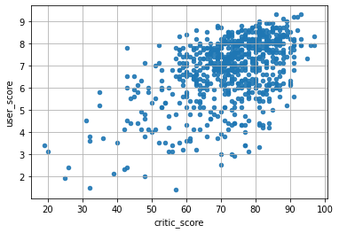

```python
corr_scatter(df_2014.query('user_score > 0 and critic_score > 0'), 'user_score', 'critic_score')
```

Наблюдается прямая зависимость средней выраженности между величиной продаж и оценкой критиков, если рассматривать данные за последние 3 года, то есть покупатель ориентируется на отзывы критиков об играх. Есть средняя прямаязависимость между оценками пользователей и критиков.

#### Построим диаграмму рассеяния и посчитайте корреляцию между отзывами и продажами для платформы PS4.

```
Зависимость продаж от отзывов пользователей

-0.04318585997193634

Диаграмма рассеяния
```

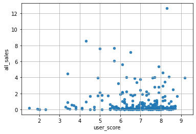

```
Зависимость продаж от отзывов критиков

0.40190287811475334

Диаграмма рассеяния
```

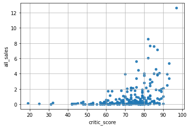

```
Зависимость между отзывами пользователей и отзывами критиков

0.546434245119031

Диаграмма рассеяния
```

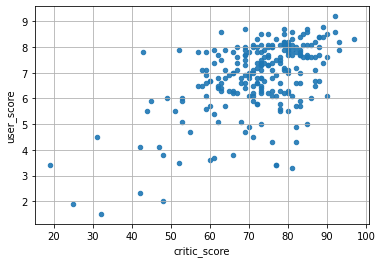

```python
corr_scatter(PS4_2014.query('user_score > 0 and critic_score > 0'), 'user_score', 'critic_score')
```

Для платформы PS4 продажи в средней степени зависят от оценки критиков. Также прослеживается средняя прямая зависимость между отзывами пользователей и отзывами критиков.

#### Построим диаграмму рассеяния и посчитайте корреляцию между отзывами и продажами для платформы XOne.

```
Зависимость продаж от отзывов пользователей

-0.09173434503310748

Диаграмма рассеяния
```

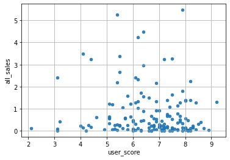

```
Зависимость продаж от отзывов критиков

0.4221118510555765

Диаграмма рассеяния
```

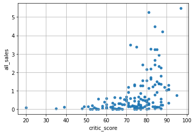

```
Зависимость между отзывами пользователей и отзывами критиков

0.44097734837644115

Диаграмма рассеяния
```

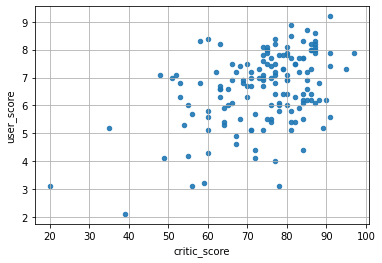

```python
corr_scatter(XOne_2014.query('user_score > 0 and critic_score > 0'), 'user_score', 'critic_score')
```

Для платформы XOne продажи в средней степени зависят от оценки критиков. Также прослеживается средняя прямая зависимость между отзывами пользователей и отзывами критиков.

#### Построим диаграмму рассеяния и посчитайте корреляцию между отзывами и продажами для платформы 3DS.

```
Зависимость продаж от отзывов пользователей

0.2798498792503281

Диаграмма рассеяния
```

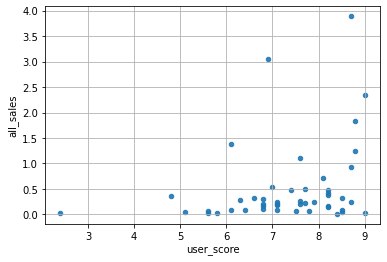

```
Зависимость продаж от отзывов критиков

0.28468579095782925

Диаграмма рассеяния
```

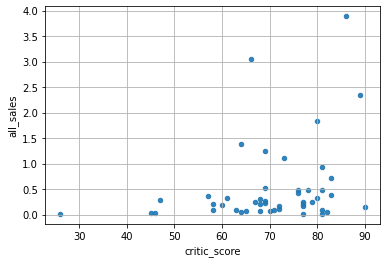

```
Зависимость между отзывами пользователей и отзывами критиков

0.862484552934546

Диаграмма рассеяния
```

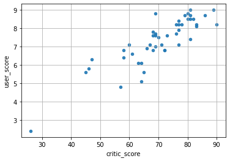

```python
corr_scatter(_3DS_2014.query('user_score > 0 and critic_score > 0'), 'user_score', 'critic_score')
```

Для платформы 3DS продажи зависят от обеих оценок, но от оценки критиков немого больше, чем от оценки пользователей. Также прослеживается сильная прямая зависимость между отзывами пользователей и отзывами критиков.

#### Построим диаграмму рассеяния и посчитайте корреляцию между отзывами и продажами для платформы PC.

```
Зависимость продаж от отзывов пользователей

0.02233225834555763

Диаграмма рассеяния
```

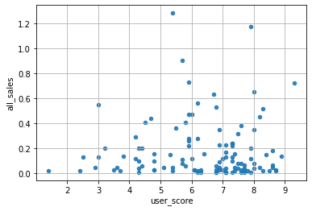

```
Зависимость продаж от отзывов критиков

0.3327284030606151

Диаграмма рассеяния
```

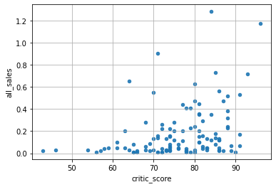

```
Зависимость между отзывами пользователей и отзывами критиков

0.46302585839115934

Диаграмма рассеяния
```

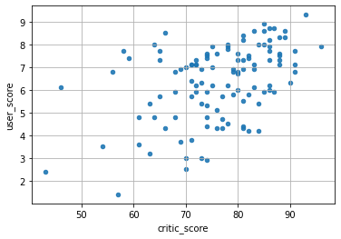

```python
corr_scatter(PC_2014.query('user_score > 0 and critic_score > 0'), 'user_score', 'critic_score')
```

### Посмотрим на общее распределение игр по жанрам.

#### Для всего исследуемого периода

```python
df.pivot_table(
    index='genre',
    values = 'all_sales',
    aggfunc='sum').query(
    'all_sales > 0').sort_values(
    by='all_sales',
    ascending=False)
```

| genre | all_sales |
| --- | --- |
| Action | 1716.52 |
| Sports | 1309.67 |
| Shooter | 1041.36 |
| Role-Playing | 931.08 |
| Platform | 825.55 |
| Misc | 790.29 |
| Racing | 723.49 |
| Fighting | 442.66 |
| Simulation | 387.96 |
| Puzzle | 239.89 |
| Adventure | 233.33 |
| Strategy | 172.57 |

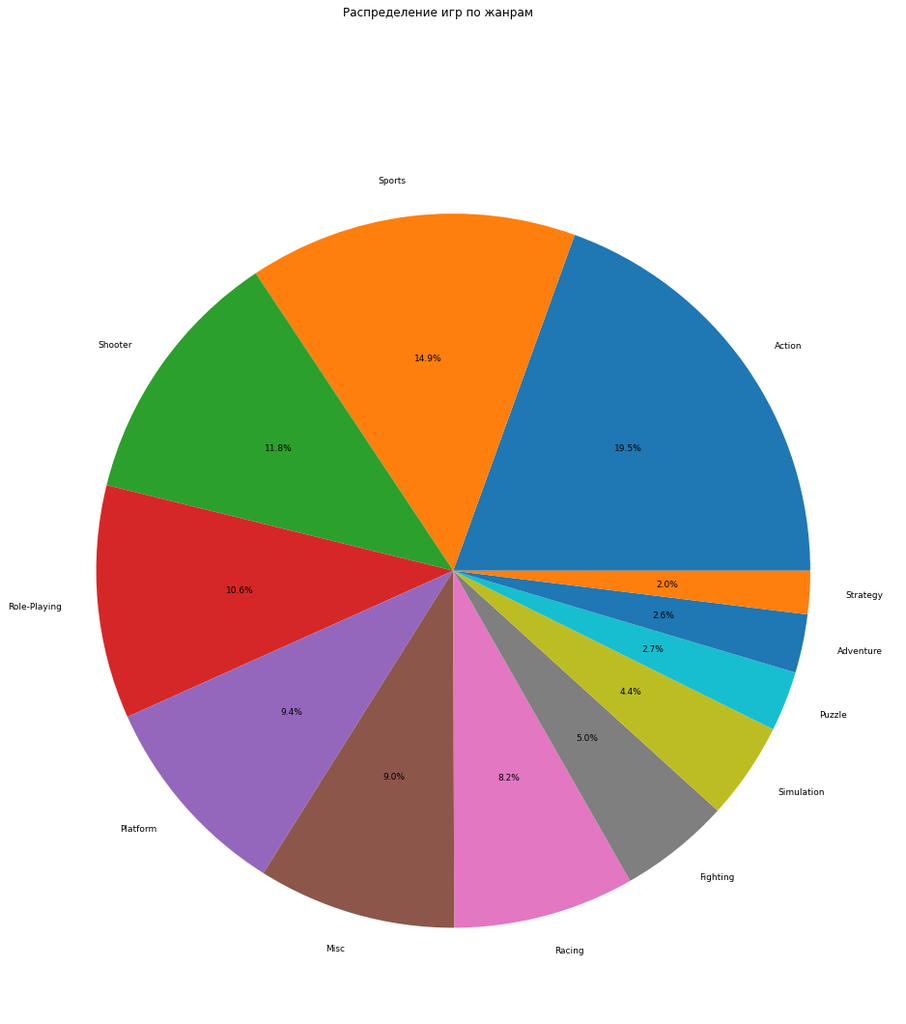

```python
df.pivot_table(
    index='genre',
    values='all_sales',
    aggfunc='sum').sort_values(
    by='all_sales',
    ascending=False).query(
    'all_sales > 0').plot(
    kind='pie',
    subplots=True,
    autopct ='%1.1f%%',
    legend=False,
    figsize=(17,17),
    fontsize=9,
    ylabel='',
    title='Распределение игр по жанрам');
```

Если рассматривать весь исследуемый период, самые популярныйе жанры: Action, Sports, Shooter, Role-Playing, Platform

#### Для последних 3 лет

```python
df_2014.pivot_table(
    index='genre',
    values = 'all_sales',
    aggfunc='sum').query(
    'all_sales > 0').sort_values(
    by='all_sales',
    ascending=False)
```

| genre | all_sales |
| --- | --- |
| Action | 199.36 |
| Shooter | 170.94 |
| Sports | 109.48 |
| Role-Playing | 101.44 |
| Misc | 37.55 |
| Fighting | 28.22 |
| Racing | 27.52 |
| Platform | 18.09 |
| Adventure | 17.55 |
| Simulation | 13.13 |
| Strategy | 3.96 |
| Puzzle | 2.21 |

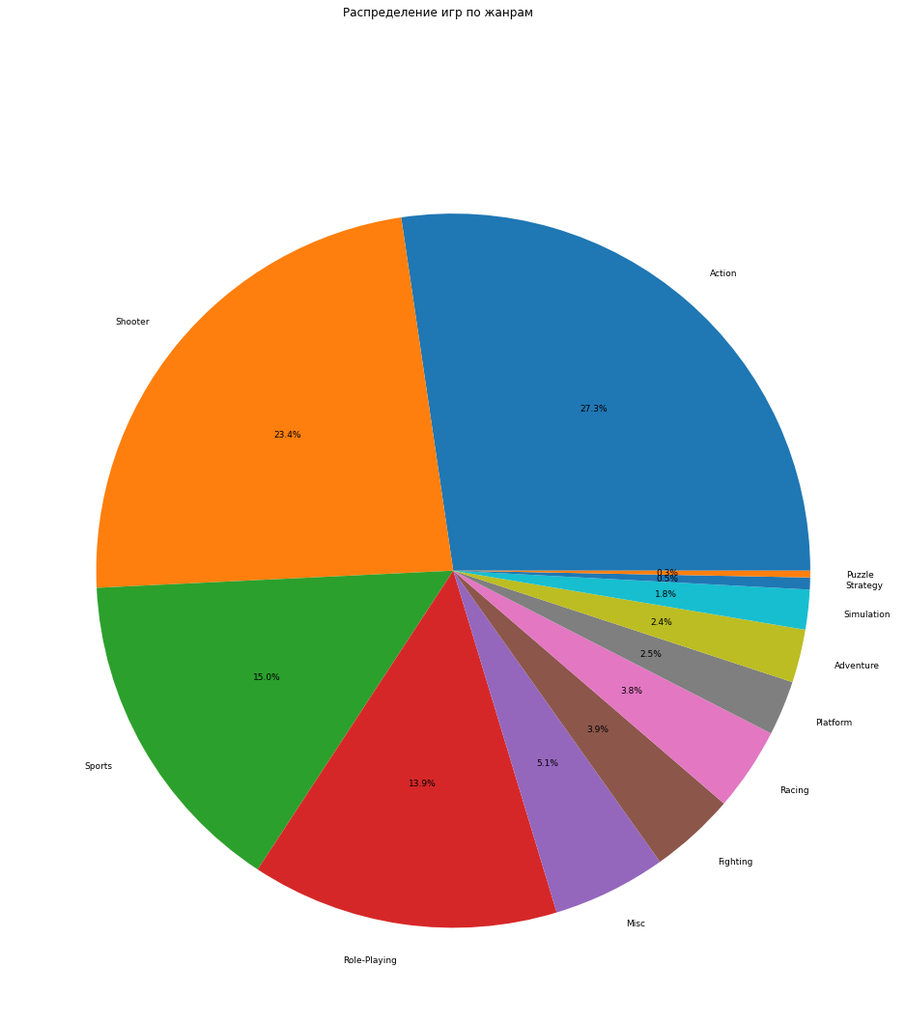

```python
df_2014.pivot_table(
    index='genre',
    values='all_sales',
    aggfunc='sum').sort_values(
    by='all_sales',
    ascending=False).query(
    'all_sales > 0').plot(
    kind='pie',
    subplots=True,
    autopct ='%1.1f%%',
    legend=False,
    figsize=(17,17),
    fontsize=9,
    ylabel='',
    title='Распределение игр по жанрам');
```

Если рассматривать последние три года, самые популярныйе жанры: Action, Shooter, Sports, Role-Playing, Misc. Жанры Action, Shooter, Sports и Role-Playing приносят более 3/4 всей прибыли за последние 3 года.

#### Рассмотрим средние и медианные размеры продаж для каждого жанра для всего исследуемого периода.

```python
df.groupby('genre')['all_sales'].describe().sort_values(by='mean', ascending=False)
```

| genre | count | mean | std | min | 25% | 50% | 75% | max |
| --- | --- | --- | --- | --- | --- | --- | --- | --- |
| Platform | 878.0 | 0.940262 | 2.587816 | 0.01 | 0.09 | 0.27 | 0.805 | 40.24 |
| Shooter | 1296.0 | 0.803519 | 1.831975 | 0.01 | 0.08 | 0.24 | 0.740 | 28.31 |
| Role-Playing | 1481.0 | 0.628683 | 1.719155 | 0.01 | 0.07 | 0.18 | 0.530 | 31.38 |
| Racing | 1226.0 | 0.590122 | 1.670875 | 0.00 | 0.07 | 0.19 | 0.530 | 35.52 |
| Sports | 2306.0 | 0.567940 | 2.099900 | 0.00 | 0.09 | 0.22 | 0.550 | 82.54 |
| Fighting | 837.0 | 0.528865 | 0.954210 | 0.01 | 0.08 | 0.21 | 0.550 | 12.84 |
| Action | 3307.0 | 0.519057 | 1.153873 | 0.01 | 0.07 | 0.19 | 0.490 | 21.05 |
| Misc | 1721.0 | 0.459204 | 1.312894 | 0.01 | 0.06 | 0.16 | 0.400 | 28.91 |
| Simulation | 857.0 | 0.452695 | 1.196965 | 0.01 | 0.05 | 0.15 | 0.420 | 24.67 |
| Puzzle | 569.0 | 0.421599 | 1.577060 | 0.01 | 0.04 | 0.10 | 0.300 | 30.26 |
| Strategy | 673.0 | 0.256419 | 0.522303 | 0.01 | 0.04 | 0.10 | 0.270 | 5.45 |
| Adventure | 1293.0 | 0.180456 | 0.505704 | 0.01 | 0.02 | 0.05 | 0.150 | 11.18 |

#### Рассмотрим средние и медианные размеры продаж для каждого жанра ъа последние 3 года.

```python
df_2014.groupby('genre')['all_sales'].describe().sort_values(by='mean', ascending=False)
```

| genre | count | mean | std | min | 25% | 50% | 75% | max |
| --- | --- | --- | --- | --- | --- | --- | --- | --- |
| Shooter | 128.0 | 1.335469 | 2.050567 | 0.01 | 0.1725 | 0.515 | 1.6175 | 14.63 |
| Sports | 161.0 | 0.680000 | 1.239736 | 0.01 | 0.0600 | 0.180 | 0.6400 | 8.58 |
| Platform | 38.0 | 0.476053 | 0.722561 | 0.01 | 0.0625 | 0.140 | 0.4675 | 3.21 |
| Fighting | 60.0 | 0.470333 | 1.188053 | 0.01 | 0.0600 | 0.125 | 0.3200 | 7.55 |
| Role-Playing | 221.0 | 0.459005 | 1.177284 | 0.01 | 0.0500 | 0.110 | 0.3600 | 11.68 |
| Racing | 69.0 | 0.398841 | 0.963716 | 0.01 | 0.0300 | 0.090 | 0.2500 | 7.09 |
| Misc | 113.0 | 0.332301 | 0.736999 | 0.01 | 0.0300 | 0.090 | 0.3200 | 5.27 |
| Action | 619.0 | 0.322068 | 0.798181 | 0.01 | 0.0300 | 0.090 | 0.2800 | 12.62 |
| Simulation | 44.0 | 0.298409 | 0.646925 | 0.01 | 0.0200 | 0.100 | 0.3275 | 3.05 |
| Puzzle | 14.0 | 0.157857 | 0.320629 | 0.01 | 0.0200 | 0.045 | 0.1000 | 1.19 |
| Strategy | 37.0 | 0.107027 | 0.118412 | 0.01 | 0.0300 | 0.060 | 0.1400 | 0.52 |
| Adventure | 185.0 | 0.094865 | 0.203147 | 0.01 | 0.0200 | 0.030 | 0.0800 | 1.66 |

В последние 3 года игры жанров Shooter и Sports стали самыми дорогими, но при этом перестали быть одними из самых частовыпускаемых. Игры жанра Action находятся в топе по продажам за счет огромного количества выпускаемых игр, при этом среднее и медианное значение продаж находятся на среднем уровне.

### Вывод:

Больше всего игр вышло в период с 2005 по 2011 года, пик пришелся на 2008-2009 год. Эти данные пригодятся, когда мы будем рассматривать продажи для каждой отдельно й платформы по годам.

За всё время наблюдений самые большие продажи у платформы PS2, далее идут X360, PS3, Wii, DS, PS, PS4 и так далее.

На 1998 пришелся пик продаж на платформе GB, на 2002 и 2004 пришлись пики продаж на платформе GBA, на 2009 - PS2, на 2010 - PS3, на 2011 - Wii, на 2015 - X360.

В среднем платформа "живёт" 7 лет, примерно половину времени платформа растет, а вторую половину - падает, поэтому примем за актуальный период 3 года. PC - платформа долгожитель (26 лет).

За последние 3 года самыми популярными платформами являются PS4, XOne и 3DS. Хотя и там заметно снижение продаж. Так же снижаются продажи игр для PC, однако эта платформа по представленным данным существует уже 26 лет, так что игры для пк будут выходить и дальше.

Для разных платформ диаграммы размаха различаются. За период 2014-2016 год для каждой платформы были выпущены 1-3 игры с высокими продажами.

Для платформ 3DS и PC медианное значение, первый и третий квартили и нормальное распределение примерно одинаковые, однако у платформы 3DS больше выбросов сверху. Для платформ PS4 и XOne медианное значение и первый квартиль находятся примерно на одном уровне, но у Xone третий квартиль выше, как и нормальное распределение, при этом у PS4 больше выбросов сверху.

Средняя выручка на игру по миру: 432 тыс. дол. 75% игр заработали до 350 тыс. Рекорд 14,63 млн.

Средняя выручка на игру по платформе PS4: 766 тыс. 75% игр заработали до 690 тыс. Рекорд 14,63 млн.

Средняя выручка на игру по платформе XOne: 616 тыс. 75% игр заработали до 633 тыс. Рекорд 7.39 млн.

Средняя выручка на игру по платформе 3DS: 409 тыс. 75% игр заработали до 250 тыс. Рекорд 11.68 млн.

Средняя выручка на игру по платформе PC: 179 тыс. 75% игр заработали до 60 тыс. Рекорд 3.05 млн.

Пропущенные (нулевые) значения встречаются и для оценок критиков и для оценок пользователей, причем для любых объемов продаж.

Наблюдается прямая зависимость продаж от оценки критиков средней выраженности, величина продаж сильнее зависит от оценки критиков, чем и от оценки пользователей, если рассматриваить весь исследуемый период (логично, человек сначала смотрит отзывы критиков, потом покупает игру, и только потом оставлет свой отзыв), то есть покупатель ориентируется на отзывы об играх. Есть средняя прямая зависимость между оценками пользователей и критиков.

Наблюдается прямая зависимость средней выраженности между величиной продаж и оценкой критиков, если рассматривать данные за последние 3 года, то есть покупатель ориентируется на отзывы критиков об играх. Есть средняя прямаязависимость между оценками пользователей и критиков.

Для платформы PS4 продажи в средней степени зависят от оценки критиков. Также прослеживается средняя прямая зависимость между отзывами пользователей и отзывами критиков.

Для платформы XOne продажи в средней степени зависят от оценки критиков. Также прослеживается средняя прямая зависимость между отзывами пользователей и отзывами критиков.

Для платформы 3DS продажи зависят от обеих оценок, но от оценки критиков немого больше, чем от оценки пользователей. Также прослеживается сильная прямая зависимость между отзывами пользователей и отзывами критиков.

Для платформы PC продажи в меньшей степени зависят от оценки критиков, чем предыдущие платформы. Также прослеживается средняя прямая зависимость между отзывами пользователей и отзывами критиков.

Если рассматривать весь исследуемый период, самые популярныйе жанры: Action, Sports, Shooter, Role-Playing, Platform.

С 1980 до 2016 года высокие продажи для жанров Action, Shooter и Sports в основном обусловлены большим количеством игр этих жанров. Для жанра Shooter и среднее и медианное значение продаж на втором месте после жанра Platform. Игр жанра Action выпускается больше всего, при этом среднее и медианное значения продаж находятся на среднем уровне. Для жанра Sports количество выпущенных игр на втором месте после жанра Action, при этом среднее и медианное значения немного выше.

Если рассматривать последние три года, самые популярныйе жанры: Action, Shooter, Sports, Role-Playing, Misc. Жанры Action, Shooter, Sports и Role-Playing приносят более 3/4 всей прибыли за последние 3 года.

В последние 3 года игры жанров Shooter и Sports стали самыми дорогими, но при этом перестали быть одними из самых частовыпускаемых. Игры жанра Action находятся в топе по продажам за счет огромного количества выпускаемых игр, при этом среднее и медианное значение продаж находятся на среднем уровне.

## Составим портрет пользователя каждого региона.

К содержанию

### Рассмотрим самые популярные (топ-5) платформы для регионов:

```python
def top (df, index, values):
    return df.pivot_table(
    index=index,
    values=values,
    aggfunc='sum').sort_values(
    by=values,
    ascending=False).head(5)
```

#### Топ-5 платформ для Северной Америки.

```python
na_top_5_platforms = top(df_2014, 'platform', 'na_sales')
```

```python
na_top_5_platforms
```

| platform | na_sales |
| --- | --- |
| PS4 | 98.61 |
| XOne | 81.27 |
| X360 | 28.30 |
| 3DS | 22.64 |
| PS3 | 22.05 |

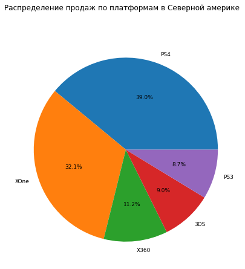

```python
na_top_5_platforms.plot(
    kind='pie',
    subplots=True,
    autopct ='%1.1f%%',
    legend=False,
    figsize=(7,7),
    fontsize=9,
    ylabel='',
    title='Распределение продаж по платформам в Северной америке');
```

Для Северной Америки самые популярные платформы PS4 - 39% продаж, XOne - 32,1% продаж, X360 - 11,2% продаж, 3DS - 9% продаж, PS3 - 8,7% продаж. PS4 и XOne занимат более двух третей рынка.

#### Топ-5 платформ для Европы.

```python
eu_top_5_platforms = top(df_2014, 'platform', 'eu_sales')
```

```python
eu_top_5_platforms
```

| platform | eu_sales |
| --- | --- |
| PS4 | 130.04 |
| XOne | 46.25 |
| PS3 | 25.54 |
| PC | 17.97 |
| 3DS | 16.12 |

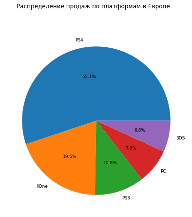

```python
eu_top_5_platforms.plot(
    kind='pie',
    subplots=True,
    autopct ='%1.1f%%',
    legend=False,
    figsize=(7,7),
    fontsize=9,
    ylabel='',
    title='Распределение продаж по платформам в Европе');
```

#### Топ-5 платформ для Японии.

```python
jp_top_5_platforms = top(df_2014, 'platform', 'jp_sales')
```

```python
jp_top_5_platforms
```

| platform | jp_sales |
| --- | --- |
| 3DS | 44.24 |
| PS4 | 15.02 |
| PSV | 14.54 |
| PS3 | 11.22 |
| WiiU | 7.31 |

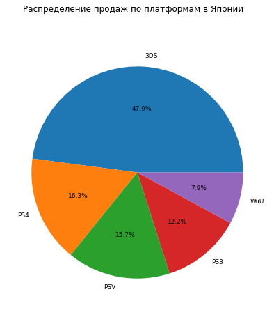

```python
jp_top_5_platforms.plot(
    kind='pie',
    subplots=True,
    autopct ='%1.1f%%',
    legend=False,
    figsize=(7,7),
    fontsize=9,
    ylabel='',
    title='Распределение продаж по платформам в Японии');
```

Для Японии самые популярные платформы 3DS - 47,9% продаж, PS4 - 16,3% продаж, PSV - 15.7% продаж, PS3 - 12.2% продаж и WiiU - 7.9% продаж. 3DS, PS4 и PSV занимают более 3/4 рынка.

#### Топ-5 платформ для остальных регионов.

```python
other_sales_top_5_platforms = top(df_2014, 'platform', 'other_sales')
```

```python
other_sales_top_5_platforms
```

| platform | other_sales |
| --- | --- |
| PS4 | 44.48 |
| XOne | 12.52 |
| PS3 | 9.37 |
| X360 | 4.35 |
| 3DS | 3.68 |

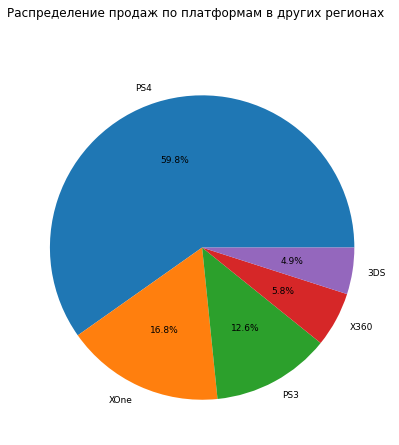

```python
other_sales_top_5_platforms.plot(
    kind='pie',
    subplots=True,
    autopct ='%1.1f%%',
    legend=False,
    figsize=(7,7),
    fontsize=9,
    ylabel='',
    title='Распределение продаж по платформам в других регионах');
```

Для других регионов самые популярные платформы PS4 - 59,8% продаж, XOne - 16,8% продаж, PS3 - 12,6% продаж, X360 - 5,8% продаж и 3DS - 4,9% продаж. PS4 и XOne занимат более 3/4 рынка.

```python
top_platforms = na_top_5_platforms.merge(
    eu_top_5_platforms, on='platform', how='outer').merge(
    jp_top_5_platforms, on='platform', how='outer').merge(
    other_sales_top_5_platforms, on='platform', how='outer').fillna(0)
```

```python
top_platforms
```

| platform | na_sales | eu_sales | jp_sales | other_sales |
| --- | --- | --- | --- | --- |
| PS4 | 98.61 | 130.04 | 15.02 | 44.48 |
| XOne | 81.27 | 46.25 | 0.00 | 12.52 |
| X360 | 28.30 | 0.00 | 0.00 | 4.35 |
| 3DS | 22.64 | 16.12 | 44.24 | 3.68 |
| PS3 | 22.05 | 25.54 | 11.22 | 9.37 |
| PC | 0.00 | 17.97 | 0.00 | 0.00 |
| PSV | 0.00 | 0.00 | 14.54 | 0.00 |
| WiiU | 0.00 | 0.00 | 7.31 | 0.00 |

[figure not shown]

```python
fig, ax = plt.subplots(figsize=(15, 8))
sns.heatmap(
    top_platforms, annot=True, fmt=".1f").set(
    title='Сравнение портретов пользователей из разных стран по платформе',
    xlabel='регион',
    ylabel='платформа');
```

### Рассмотрим самые популярные жанры (топ-5) для регионов:

#### Топ-5 жанров для Северной Америки.

```python
na_top_5_genres = top(df_2014, 'genre', 'na_sales')
```

```python
na_top_5_genres
```

| genre | na_sales |
| --- | --- |
| Shooter | 79.02 |
| Action | 72.53 |
| Sports | 46.13 |
| Role-Playing | 33.47 |
| Misc | 15.05 |

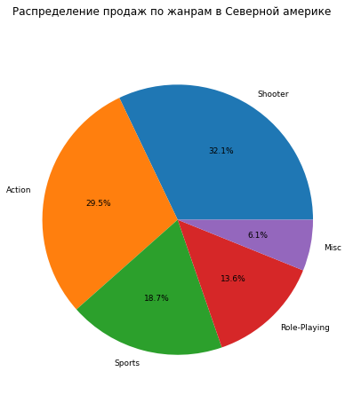

```python
na_top_5_genres.plot(
    kind='pie',
    subplots=True,
    autopct ='%1.1f%%',
    legend=False,
    figsize=(7,7),
    fontsize=9,
    ylabel='',
    title='Распределение продаж по жанрам в Северной америке');
```

Для Северной Америки самые популярные жанры Shooter - 32,1%, Action - 29,5%, Sports - 18,7%, Role-Playing - 13,6%, Misс - 6,1%. Shooter, Action и Sports занимат более 3/4 рынка.

#### Топ-5 жанров для Европы.

```python
eu_top_5_genres = top(df_2014, 'genre', 'eu_sales')
```

```python
eu_top_5_genres
```

| genre | eu_sales |
| --- | --- |
| Action | 74.68 |
| Shooter | 65.52 |
| Sports | 45.73 |
| Role-Playing | 28.17 |
| Racing | 14.13 |

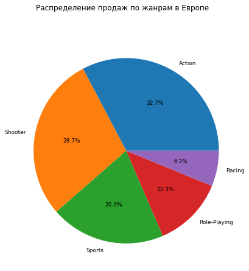

```python
eu_top_5_genres.plot(
    kind='pie',
    subplots=True,
    autopct ='%1.1f%%',
    legend=False,
    figsize=(7,7),
    fontsize=9,
    ylabel='',
    title='Распределение продаж по жанрам в Европе');
```

Для Европы самые популярные жанры Action - 32,7%, Shooter - 28,7%, Sports - 20%, Role-Playing - 12,3%, Racing - 6,2%. Action, Shooter и Sports занимат более 3/4 рынка.

#### Топ-5 жанров для Японии.

```python
jp_top_5_genres = top(df_2014, 'genre', 'jp_sales')
```

```python
jp_top_5_genres
```

| genre | jp_sales |
| --- | --- |
| Role-Playing | 31.16 |
| Action | 29.58 |
| Fighting | 6.37 |
| Misc | 5.61 |
| Shooter | 4.87 |

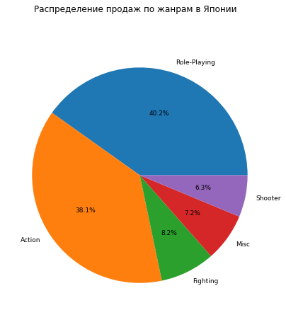

```python
jp_top_5_genres.plot(
    kind='pie',
    subplots=True,
    autopct ='%1.1f%%',
    legend=False,
    figsize=(7,7),
    fontsize=9,
    ylabel='',
    title='Распределение продаж по жанрам в Японии');
```

#### Топ-5 жанров для остальных регионов.

```python
other_sales_top_5_genres = top(df_2014, 'genre', 'other_sales')
```

```python
other_sales_top_5_genres
```

| genre | other_sales |
| --- | --- |
| Action | 22.57 |
| Shooter | 21.53 |
| Sports | 14.36 |
| Role-Playing | 8.64 |
| Misc | 4.03 |

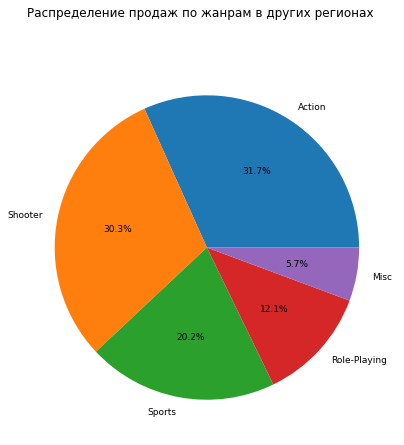

```python
other_sales_top_5_genres.plot(
    kind='pie',
    subplots=True,
    autopct ='%1.1f%%',
    legend=False,
    figsize=(7,7),
    fontsize=9,
    ylabel='',
    title='Распределение продаж по жанрам в других регионах');
```

Для других регионов самые популярные жанры Action - 31,7%, Shooter - 30,3%, Sports - 20,2%, Role-Playing - 12,1%, Misc - 5,7%. Action, Shooter и Sports занимат более 3/4 рынка.

```python
top_genres = na_top_5_genres.merge(
    eu_top_5_genres, on='genre', how='outer').merge(
    jp_top_5_genres, on='genre', how='outer').merge(
    other_sales_top_5_genres, on='genre', how='outer').fillna(0)
```

```python
top_genres
```

| genre | na_sales | eu_sales | jp_sales | other_sales |
| --- | --- | --- | --- | --- |
| Shooter | 79.02 | 65.52 | 4.87 | 21.53 |
| Action | 72.53 | 74.68 | 29.58 | 22.57 |
| Sports | 46.13 | 45.73 | 0.00 | 14.36 |
| Role-Playing | 33.47 | 28.17 | 31.16 | 8.64 |
| Misc | 15.05 | 0.00 | 5.61 | 4.03 |
| Racing | 0.00 | 14.13 | 0.00 | 0.00 |
| Fighting | 0.00 | 0.00 | 6.37 | 0.00 |

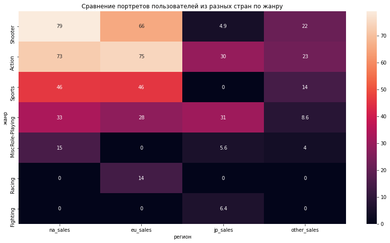

```python
fig, ax = plt.subplots(figsize=(15, 8))
sns.heatmap(
    top_genres, annot=True).set(
    title='Сравнение портретов пользователей из разных стран по жанру',
    xlabel='регион',
    ylabel='жанр');
```

### Определим влияет ли рейтинг ESRB на продажи в регионе:

#### Влияние рейтинга ESRB на продажи в Северной Америке.

```python
na_top_5_ratings = top(df_2014.query('rating != "unknown"'), 'rating', 'na_sales')
```

```python
na_top_5_ratings
```

| rating | na_sales |
| --- | --- |
| M | 96.42 |
| E | 50.74 |
| T | 38.95 |
| E10+ | 33.23 |

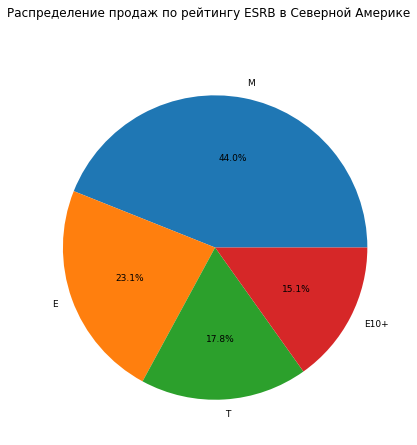

```python
na_top_5_ratings.plot(
    kind='pie',
    subplots=True,
    autopct ='%1.1f%%',
    legend=False,
    figsize=(7,7),
    fontsize=9,
    ylabel='',
    title='Распределение продаж по рейтингу ESRB в Северной Америке');
```

Для Северной Америки самые популярные рейтинги M - 44%, E - 23.1%, T - 17.8%, E10+ - 15.1%. Для остальных рейтингов продажи равны 0. Похоже в Северной Америке существует только 4 рейтинга игр.

#### Влияние рейтинга ESRB на продажи в Европе.

```python
eu_top_5_ratings = top(df_2014.query('rating != "unknown"'), 'rating', 'eu_sales')
```

```python
eu_top_5_ratings
```

| rating | eu_sales |
| --- | --- |
| M | 93.44 |
| E | 58.06 |
| T | 34.07 |
| E10+ | 26.16 |

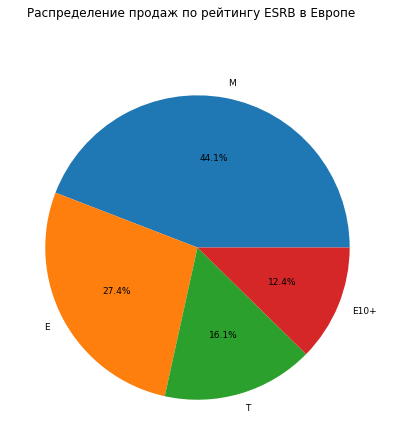

```python
eu_top_5_ratings.plot(
    kind='pie',
    subplots=True,
    autopct ='%1.1f%%',
    legend=False,
    figsize=(7,7),
    fontsize=9,
    ylabel='',
    title='Распределение продаж по рейтингу ESRB в Европе');
```

Для Европы самые популярные рейтинги M - 44,1%, E - 27,4%, T - 16,1%, E10+ - 12,4%. Для остальных рейтингов продажи равны 0. Похоже в Европе существует только 4 рейтинга игр.

#### Влияние рейтинга ESRB на продажи в Японии.

```python
jp_top_5_ratings = top(df_2014.query('rating != "unknown"'), 'rating', 'jp_sales')
```

```python
jp_top_5_ratings
```

| rating | jp_sales |
| --- | --- |
| T | 14.78 |
| E | 8.94 |
| M | 8.01 |
| E10+ | 4.46 |

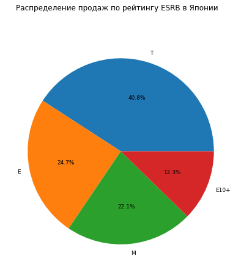

```python
jp_top_5_ratings.plot(
    kind='pie',
    subplots=True,
    autopct ='%1.1f%%',
    legend=False,
    figsize=(7,7),
    fontsize=9,
    ylabel='',
    title='Распределение продаж по рейтингу ESRB в Японии');
```

Для Японии самые популярные рейтинги Т - 40,8%, E - 24,7%, М - 22,1%, E10+ - 12,3%. Для остальных рейтингов продажи равны 0. Похоже в Японии существует только 4 рейтинга игр.

#### Влияние рейтинга ESRB на продажи в других регионах.

```python
other_sales_top_5_ratings = top(df_2014.query('rating != "unknown"'), 'rating', 'other_sales')
```

```python
other_sales_top_5_ratings
```

| rating | other_sales |
| --- | --- |
| M | 28.67 |
| E | 15.39 |
| T | 11.33 |
| E10+ | 7.83 |

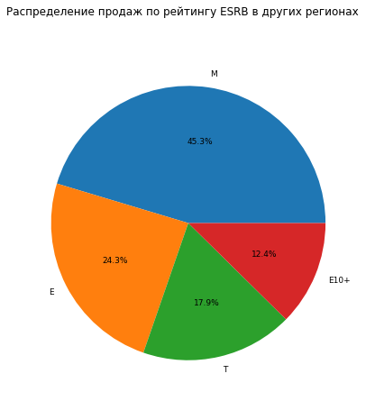

```python
other_sales_top_5_ratings.plot(
    kind='pie',
    subplots=True,
    autopct ='%1.1f%%',
    legend=False,
    figsize=(7,7),
    fontsize=9,
    ylabel='',
    title='Распределение продаж по рейтингу ESRB в других регионах');
```

Для Других регионов самые популярные рейтинги М - 45,3%, E - 24,3%, Т - 17,9%, E10+ - 12,4%. Для остальных рейтингов продажи равны 0. Похоже в других регионах существует только 4 рейтинга игр.

```python
top_ratings = na_top_5_ratings.merge(
    eu_top_5_ratings, on='rating', how='outer').merge(
    jp_top_5_ratings, on='rating', how='outer').merge(
    other_sales_top_5_ratings, on='rating', how='outer').head(4)
```

```python
top_ratings
```

| rating | na_sales | eu_sales | jp_sales | other_sales |
| --- | --- | --- | --- | --- |
| M | 96.42 | 93.44 | 8.01 | 28.67 |
| E | 50.74 | 58.06 | 8.94 | 15.39 |
| T | 38.95 | 34.07 | 14.78 | 11.33 |
| E10+ | 33.23 | 26.16 | 4.46 | 7.83 |

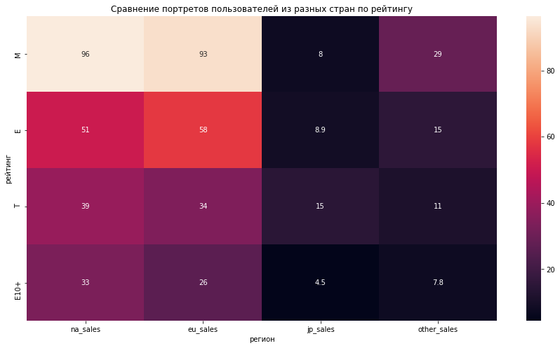

```python
fig, ax = plt.subplots(figsize=(15, 8))
sns.heatmap(
    top_ratings, annot=True).set(
    title='Сравнение портретов пользователей из разных стран по рейтингу',
    xlabel='регион',
    ylabel='рейтинг');
```

### Рассмотрим самые попуряные игры по регионам за 2016 год.

#### Самые популярные игры в Северной Америке.

```python
na_top_5_games_2016 = top(df_2014.query('year_of_release == 2016'), 'name', 'na_sales')
```

```python
na_top_5_games_2016
```

| name | na_sales |
| --- | --- |
| Call of Duty: Infinite Warfare | 3.11 |
| Pokemon Sun/Moon | 2.98 |
| Tom Clancy's The Division | 2.86 |
| Madden NFL 17 | 2.54 |
| Battlefield 1 | 2.49 |

```python
na_top_5_games_2016.index
```

```
Index(['Call of Duty: Infinite Warfare', 'Pokemon Sun/Moon',
       'Tom Clancy's The Division', 'Madden NFL 17', 'Battlefield 1'],
      dtype='object', name='name')
```

**Самые популярные игры в Северной Америке:** 'Call of Duty: Infinite Warfare', 'Pokemon Sun/Moon', 'Tom Clancy's The Division', 'Madden NFL 17', 'Battlefield 1'

#### Самые популярные игры в Европе.

```python
eu_top_5_games_2016 = top(df_2014.query('year_of_release == 2016'), 'name', 'eu_sales')
```

```python
eu_top_5_games_2016
```

| name | eu_sales |
| --- | --- |
| FIFA 17 | 8.74 |
| Battlefield 1 | 3.16 |
| Call of Duty: Infinite Warfare | 2.82 |
| Tom Clancy's The Division | 2.53 |
| Uncharted 4: A Thief's End | 2.50 |

```python
eu_top_5_games_2016.index
```

```
Index(['FIFA 17', 'Battlefield 1', 'Call of Duty: Infinite Warfare',
       'Tom Clancy's The Division', 'Uncharted 4: A Thief's End'],
      dtype='object', name='name')
```

#### Самые популярные игры в Японии.

```python
jp_top_5_games_2016 = top(df_2014.query('year_of_release == 2016'), 'name', 'jp_sales')
```

```python
jp_top_5_games_2016
```

| name | jp_sales |
| --- | --- |
| Pokemon Sun/Moon | 2.26 |
| Yokai Watch 3 | 1.33 |
| Dragon Quest Builders: Revive Alefgard | 0.64 |
| Dragon Quest Heroes II: Twin Kings and the Prophecy's End | 0.64 |
| Dragon Quest Monsters Joker 3 | 0.63 |

```python
jp_top_5_games_2016.index
```

```
Index(['Pokemon Sun/Moon', 'Yokai Watch 3',
       'Dragon Quest Builders: Revive Alefgard',
       'Dragon Quest Heroes II: Twin Kings and the Prophecy's End',
       'Dragon Quest Monsters Joker 3'],
      dtype='object', name='name')
```

#### Самые популярные игры в других регионах.

```python
other_sales_top_5_games_2016 = top(df_2014.query('year_of_release == 2016'), 'name', 'other_sales')
```

```python
other_sales_top_5_games_2016
```

| name | other_sales |
| --- | --- |
| FIFA 17 | 1.42 |
| Call of Duty: Infinite Warfare | 0.94 |
| Uncharted 4: A Thief's End | 0.85 |
| Battlefield 1 | 0.84 |
| Tom Clancy's The Division | 0.84 |

```python
other_sales_top_5_games_2016.index
```

```
Index(['FIFA 17', 'Call of Duty: Infinite Warfare',
       'Uncharted 4: A Thief's End', 'Battlefield 1',
       'Tom Clancy's The Division'],
      dtype='object', name='name')
```

```python
top_games_2016 = na_top_5_games_2016.merge(
    eu_top_5_games_2016, on='name', how='outer').merge(
    jp_top_5_games_2016, on='name', how='outer').merge(
    other_sales_top_5_games_2016, on='name', how='outer').fillna(0)
```

```python
top_games_2016
```

| name | na_sales | eu_sales | jp_sales | other_sales |
| --- | --- | --- | --- | --- |
| Call of Duty: Infinite Warfare | 3.11 | 2.82 | 0.00 | 0.94 |
| Pokemon Sun/Moon | 2.98 | 0.00 | 2.26 | 0.00 |
| Tom Clancy's The Division | 2.86 | 2.53 | 0.00 | 0.84 |
| Madden NFL 17 | 2.54 | 0.00 | 0.00 | 0.00 |
| Battlefield 1 | 2.49 | 3.16 | 0.00 | 0.84 |
| FIFA 17 | 0.00 | 8.74 | 0.00 | 1.42 |
| Uncharted 4: A Thief's End | 0.00 | 2.50 | 0.00 | 0.85 |
| Yokai Watch 3 | 0.00 | 0.00 | 1.33 | 0.00 |
| Dragon Quest Builders: Revive Alefgard | 0.00 | 0.00 | 0.64 | 0.00 |
| Dragon Quest Heroes II: Twin Kings and the Prophecy's End | 0.00 | 0.00 | 0.64 | 0.00 |
| Dragon Quest Monsters Joker 3 | 0.00 | 0.00 | 0.63 | 0.00 |

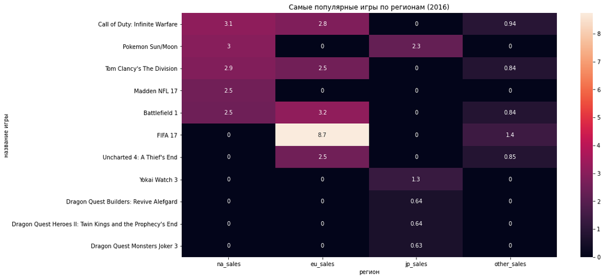

```python
fig, ax = plt.subplots(figsize=(15, 8))
sns.heatmap(
    top_games_2016, annot=True).set(
    title='Самые популярные игры по регионам (2016)',
    xlabel='регион',
    ylabel='название игры');
```

#### Создадим срез с самыми продаваемыми играми за 2016 год.

```python
tg_2016 = df.query('name.isin(@top_games_2016.index)')
```

```python
tg_2016
```

|  | name | platform | year_of_release | genre | na_sales | eu_sales | jp_sales | other_sales | critic_score | user_score | rating | all_sales |
| --- | --- | --- | --- | --- | --- | --- | --- | --- | --- | --- | --- | --- |
| 94 | FIFA 17 | PS4 | 2016 | Sports | 0.66 | 5.75 | 0.08 | 1.11 | 85 | 5.0 | E | 7.60 |
| 108 | Pokemon Sun/Moon | 3DS | 2016 | Role-Playing | 2.98 | 1.45 | 2.26 | 0.45 | 0 | 0.0 | unknown | 7.14 |
| 171 | Uncharted 4: A Thief's End | PS4 | 2016 | Shooter | 1.85 | 2.50 | 0.19 | 0.85 | 93 | 7.9 | T | 5.39 |
| 245 | Call of Duty: Infinite Warfare | PS4 | 2016 | Shooter | 1.61 | 2.00 | 0.15 | 0.71 | 77 | 3.4 | M | 4.47 |
| 289 | Battlefield 1 | PS4 | 2016 | Shooter | 1.10 | 2.15 | 0.21 | 0.61 | 88 | 8.4 | M | 4.07 |
| 325 | Tom Clancy's The Division | PS4 | 2016 | Shooter | 1.35 | 1.70 | 0.15 | 0.60 | 80 | 7.0 | M | 3.80 |
| 571 | FIFA 17 | XOne | 2016 | Sports | 0.43 | 2.05 | 0.00 | 0.17 | 84 | 5.5 | E | 2.65 |
| 640 | Call of Duty: Infinite Warfare | XOne | 2016 | Shooter | 1.46 | 0.74 | 0.00 | 0.22 | 78 | 3.1 | M | 2.42 |
| 709 | Battlefield 1 | XOne | 2016 | Shooter | 1.28 | 0.77 | 0.00 | 0.20 | 87 | 8.2 | M | 2.25 |
| 758 | Tom Clancy's The Division | XOne | 2016 | Shooter | 1.29 | 0.68 | 0.00 | 0.20 | 80 | 6.9 | M | 2.17 |
| 1007 | Madden NFL 17 | PS4 | 2016 | Sports | 1.25 | 0.17 | 0.00 | 0.32 | 82 | 4.9 | E | 1.74 |
| 1466 | Yokai Watch 3 | 3DS | 2016 | Action | 0.00 | 0.00 | 1.33 | 0.00 | 0 | 0.0 | unknown | 1.33 |
| 1615 | Madden NFL 17 | XOne | 2016 | Sports | 1.08 | 0.02 | 0.00 | 0.13 | 83 | 5.9 | E | 1.23 |
| 2782 | FIFA 17 | PS3 | 2016 | Sports | 0.05 | 0.55 | 0.03 | 0.10 | 0 | 3.3 | E | 0.73 |
| 3177 | Dragon Quest Monsters Joker 3 | 3DS | 2016 | Role-Playing | 0.00 | 0.00 | 0.63 | 0.00 | 0 | 0.0 | unknown | 0.63 |
| 4693 | Tom Clancy's The Division | PC | 2016 | Shooter | 0.22 | 0.15 | 0.00 | 0.04 | 79 | 5.8 | M | 0.41 |
| 4768 | Dragon Quest Builders: Revive Alefgard | PS4 | 2016 | Role-Playing | 0.04 | 0.11 | 0.22 | 0.03 | 0 | 0.0 | unknown | 0.40 |
| 5000 | Battlefield 1 | PC | 2016 | Shooter | 0.11 | 0.24 | 0.00 | 0.03 | 88 | 7.6 | M | 0.38 |
| 5010 | FIFA 17 | X360 | 2016 | Sports | 0.07 | 0.28 | 0.00 | 0.03 | 0 | 1.7 | E | 0.38 |
| 5898 | Dragon Quest Builders: Revive Alefgard | PSV | 2016 | Role-Playing | 0.00 | 0.00 | 0.30 | 0.00 | 0 | 0.0 | unknown | 0.30 |
| 6085 | Dragon Quest Heroes II: Twin Kings and the Pro... | PS4 | 2016 | Action | 0.00 | 0.00 | 0.28 | 0.00 | 0 | 0.0 | unknown | 0.28 |
| 6951 | Dragon Quest Heroes II: Twin Kings and the Pro... | PSV | 2016 | Action | 0.00 | 0.00 | 0.23 | 0.00 | 0 | 0.0 | unknown | 0.23 |
| 8265 | Madden NFL 17 | X360 | 2016 | Sports | 0.14 | 0.02 | 0.00 | 0.02 | 0 | 0.7 | E | 0.18 |
| 9292 | Call of Duty: Infinite Warfare | PC | 2016 | Shooter | 0.04 | 0.08 | 0.00 | 0.01 | 73 | 3.0 | M | 0.13 |
| 9360 | Dragon Quest Heroes II: Twin Kings and the Pro... | PS3 | 2016 | Action | 0.00 | 0.00 | 0.13 | 0.00 | 0 | 0.0 | unknown | 0.13 |
| 9833 | Dragon Quest Builders: Revive Alefgard | PS3 | 2016 | Role-Playing | 0.00 | 0.00 | 0.12 | 0.00 | 0 | 0.0 | unknown | 0.12 |
| 9955 | FIFA 17 | PC | 2016 | Sports | 0.00 | 0.11 | 0.00 | 0.01 | 84 | 4.2 | E | 0.12 |
| 9970 | Madden NFL 17 | PS3 | 2016 | Sports | 0.07 | 0.02 | 0.00 | 0.02 | 0 | 0.2 | E | 0.11 |

### Вывод:

Для Северной Америки самые популярные платформы PS4 - 39% продаж, XOne - 32,1% продаж, X360 - 11,2% продаж, 3DS - 9% продаж, PS3 - 8,7% продаж. PS4 и XOne занимат более двух третей рынка.

Для Японии самые популярные платформы 3DS - 47,9% продаж, PS4 - 16,3% продаж, PSV - 15.7% продаж, PS3 - 12.2% продаж и WiiU - 7.9% продаж. 3DS, PS4 и PSV занимают более 3/4 рынка.

Для других регионов самые популярные платформы PS4 - 59,8% продаж, XOne - 16,8% продаж, PS3 - 12,6% продаж, X360 - 5,8% продаж и 3DS - 4,9% продаж. PS4 и XOne занимат более 3/4 рынка.

Для Северной Америки самые популярные жанры Shooter - 32,1%, Action - 29,5%, Sports - 18,7%, Role-Playing - 13,6%, Misс - 6,1%. Shooter, Action и Sports занимат более 3/4 рынка.

Для Европы самые популярные жанры Action - 32,7%, Shooter - 28,7%, Sports - 20%, Role-Playing - 12,3%, Racing - 6,2%. Action, Shooter и Sports занимат более 3/4 рынка.

Для других регионов самые популярные жанры Action - 31,7%, Shooter - 30,3%, Sports - 20,2%, Role-Playing - 12,1%, Misc - 5,7%. Action, Shooter и Sports занимат более 3/4 рынка.

Для Северной Америки самые популярные рейтинги M - 44%, E - 23.1%, T - 17.8%, E10+ - 15.1%. Для остальных рейтингов продажи равны 0.

Для Европы самые популярные рейтинги M - 44,1%, E - 27,4%, T - 16,1%, E10+ - 12,4%. Для остальных рейтингов продажи равны 0.

Для Японии самые популярные рейтинги Т - 40,8%, E - 24,7%, М - 22,1%, E10+ - 12,3%. Для остальных рейтингов продажи равны 0.

Для Других регионов самые популярные рейтинги М - 45,3%, E - 24,3%, Т - 17,9%, E10+ - 12,4%. Для остальных рейтингов продажи равны 0.

Похоже для всех исследуемых регионов существует только 4 категории.

Для Северной Америки самые популярные игры: 'Call of Duty: Infinite Warfare', 'Pokemon Sun/Moon', 'Tom Clancy's The Division', 'Madden NFL 17', 'Battlefield 1'.

Для Европы самые популярные игры: 'FIFA 17', 'Battlefield 1', 'Call of Duty: Infinite Warfare', 'Tom Clancy's The Division', 'Uncharted 4: A Thief's End'.

Для Японии самые популярные игры: 'Pokemon Sun/Moon', 'Yokai Watch 3', 'Dragon Quest Builders: Revive Alefgard', 'Dragon Quest Heroes II: Twin Kings and the Prophecy's End', 'Dragon Quest Monsters Joker 3'.

Для Других регионов самые популярные игры: 'FIFA 17', 'Call of Duty: Infinite Warfare', 'Uncharted 4: A Thief's End', 'Battlefield 1', 'Tom Clancy's The Division'.

Был создан Датафрейм с самыми продаваемыми играми за 2016 год. Первая по продажам - FIFA 17 для PS4(Sports), далее Pokemon Sun/Moon для 3DS (Role-Playing), далее верхушку списка занимают шуттеры для платформы PS4, потом те же уттеры, но для платформы XOne.

## Проверка гипотез.

К содержанию

### Средние пользовательские рейтинги платформ Xbox One и PC одинаковые.

Нулевая гипотеза: Средние пользовательские рейтинги платформ Xbox One и PC одинаковые. Альтернативная гипотеза: Средние пользовательские рейтинги платформ Xbox One и PC разные.

```python
alpha = 0.05
results = st.ttest_ind(df_2014.query('platform == "XOne"')['user_score'], df_2014.query('platform == "PC"')['user_score'])

print('p-значение:', results.pvalue)

if results.pvalue < alpha:
    print('Отвергаем нулевую гипотезу')
else:
    print('Не получилось отвергнуть нулевую гипотезу')
```

```
p-значение: 0.32800030965842586
Не получилось отвергнуть нулевую гипотезу
```

### Средние пользовательские рейтинги жанров Action (англ. «действие», экшен-игры) и Sports (англ. «спортивные соревнования») разные.

Нулевая гипотеза: Средние пользовательские рейтинги жанров Action (англ. «действие», экшен-игры) и Sports (англ. «спортивные соревнования») одинаковые. Альтернативная гипотеза: Средние пользовательские рейтинги жанров Action (англ. «действие», экшен-игры) и Sports (англ. «спортивные соревнования») разные

```python
alpha = 0.05
results = st.ttest_ind(df_2014.query('genre == "Action"')['user_score'], df_2014.query('genre == "Sports"')['user_score'])

print('p-значение:', results.pvalue)

if results.pvalue < alpha:
    print('Отвергаем нулевую гипотезу')
else:
    print('Не получилось отвергнуть нулевую гипотезу')
```

```
p-значение: 0.003247568418715718
Отвергаем нулевую гипотезу
```

При уровне статистической значимости 5%, наблюдаемое значение слишком далеко от предполагаемого в нулевой гипотезе, поэтому гипотеза отвергается. Средние пользовательские рейтинги жанров Action (англ. «действие», экшен-игры) и Sports (англ. «спортивные соревнования») разные.

### Вывод:

По гипотезам сделаны следующие выводы:

Средние пользовательские рейтинги жанров Action (англ. «действие», экшен-игры) и Sports (англ. «спортивные соревнования») разные.

## Общий вывод:

К содержанию

Таблица содержит исторические данные о продажах игр, оценки пользователей и экспертов, жанры и платформы и состоит из 11 столбцов:

Name — название игры

Platform — платформа

Year_of_Release — год выпуска

Genre — жанр игры

NA_sales — продажи в Северной Америке (миллионы проданных копий)

EU_sales — продажи в Европе (миллионы проданных копий)

JP_sales — продажи в Японии (миллионы проданных копий)

Other_sales — продажи в других странах (миллионы проданных копий)

Critic_Score — оценка критиков (максимум 100)

User_Score — оценка пользователей (максимум 10)

Rating — рейтинг от организации ESRB (англ. Entertainment Software Rating Board). Эта ассоциация определяет рейтинг компьютерных игр и присваивает им подходящую возрастную категорию.

В таблице присутствуют строковые и числовые значения, есть пропуски в столбцах с названем игры, годом выпуска (пропущено 2% данных), оценкой критиков (51%), оценкой пользователей (40%) и рейтингом от организации ESRB (40%), дубликатов в таблице нет.

На этапе предобработки данных все названия столбцов были приведены к нижнему регистру.

Были обработаны пропуски.

Строки с пропусками в названии игр, годе выпуска и жанре были удалены, так как не несли полезной информации и их количество было небольшим, поэтому их удаление не повлияло на репрезантивность выборки.

Строки с пропусками в оценке пользователей и оценке критиков удалить нельзя, так как их количество очень велико, пропуски и значения "tbd" были заменены на индикаторное значение - 0, так как рейтинг узнать нет возможности, а заполнение любым рассчетным значением исказит реальные данные.

Строки с пропусками в рейтинге от организации ESRB, так же нельзя удалить, и заполнить рассчетным значением, поээтому они были заполнены индикаторным значением "unknown".

Данные были преобразованы в нужные типы.

Данные о годе выпуска и оценке критиков можно заменить на целочисленный, так как в них нет дробных частей.

Пропуски в данных могут быть обусловлены техническими или человеческими факторами, некоторые данные могут отсутствовать для недавно вышедших или очень старых игр.

Данные об оценке пользователей удалось изменить с объектного типа на числовой, благодаря тому что значение "tbd" было заменено на 0, это упростит дальнейшую работу и значительно сократит использование памяти.

В таблицу был добавлен новый столбец "all_sales" содержащий суммарные объемы продаж во всех исследуемых регионах (в миллионах проданных копий).

Больше всего игр вышло в период с 2005 по 2011 года, пик пришелся на 2008-2009 год. Эти данные пригодятся, когда мы будем рассматривать продажи для каждой отдельно й платформы по годам.

За всё время наблюдений самые большие продажи у платформы PS2, далее идут X360, PS3, Wii, DS, PS, PS4 и так далее.

На 1998 пришелся пик продаж на платформе GB, на 2002 и 2004 пришлись пики продаж на платформе GBA, на 2009 - PS2, на 2010 - PS3, на 2011 - Wii, на 2015 - X360.

В среднем платформа "живёт" 7 лет, примерно половину времени платформа растет, а вторую половину - падает, поэтому примем за актуальный период 3 года. PC - платформа долгожитель (26 лет).

За последние 3 года самыми популярными платформами являются PS4, XOne и 3DS. Хотя и там заметно снижение продаж. Так же снижаются продажи игр для PC, однако эта платформа по представленным данным существует уже 26 лет, так что игры для пк будут выходить и дальше.

Для разных платформ диаграммы размаха различаются. За период 2014-2016 год для каждой платформы были выпущены 1-3 игры с высокими продажами.

Для платформ 3DS и PC медианное значение, первый и третий квартили и нормальное распределение примерно одинаковые, однако у платформы 3DS больше выбросов сверху. Для платформ PS4 и XOne медианное значение и первый квартиль находятся примерно на одном уровне, но у Xone третий квартиль выше, как и нормальное распределение, при этом у PS4 больше выбросов сверху.

Средняя выручка на игру по миру: 432 тыс. дол. 75% игр заработали до 350 тыс. Рекорд 14,63 млн.

Средняя выручка на игру по платформе PS4: 766 тыс. 75% игр заработали до 690 тыс. Рекорд 14,63 млн.

Средняя выручка на игру по платформе XOne: 616 тыс. 75% игр заработали до 633 тыс. Рекорд 7.39 млн.

Средняя выручка на игру по платформе 3DS: 409 тыс. 75% игр заработали до 250 тыс. Рекорд 11.68 млн.

Средняя выручка на игру по платформе PC: 179 тыс. 75% игр заработали до 60 тыс. Рекорд 3.05 млн.

Пропущенные (нулевые) значения встречаются и для оценок критиков и для оценок пользователей, причем для любых объемов продаж.

Наблюдается прямая зависимость продаж от оценки критиков средней выраженности, величина продаж сильнее зависит от оценки критиков, чем и от оценки пользователей, если рассматриваить весь исследуемый период (логично, человек сначала смотрит отзывы критиков, потом покупает игру, и только потом оставлет свой отзыв), то есть покупатель ориентируется на отзывы об играх. Есть средняя прямая зависимость между оценками пользователей и критиков.

Наблюдается прямая зависимость средней выраженности между величиной продаж и оценкой критиков, если рассматривать данные за последние 3 года, то есть покупатель ориентируется на отзывы критиков об играх. Есть средняя прямаязависимость между оценками пользователей и критиков.

Для платформы PS4 продажи в средней степени зависят от оценки критиков. Также прослеживается средняя прямая зависимость между отзывами пользователей и отзывами критиков.

Для платформы XOne продажи в средней степени зависят от оценки критиков. Также прослеживается средняя прямая зависимость между отзывами пользователей и отзывами критиков.

Для платформы 3DS продажи зависят от обеих оценок, но от оценки критиков немого больше, чем от оценки пользователей. Также прослеживается сильная прямая зависимость между отзывами пользователей и отзывами критиков.

Для платформы PC продажи в меньшей степени зависят от оценки критиков, чем предыдущие платформы. Также прослеживается средняя прямая зависимость между отзывами пользователей и отзывами критиков.

Если рассматривать весь исследуемый период, самые популярныйе жанры: Action, Sports, Shooter, Role-Playing, Platform.

С 1980 до 2016 года высокие продажи для жанров Action, Shooter и Sports в основном обусловлены большим количеством игр этих жанров. Для жанра Shooter и среднее и медианное значение продаж на втором месте после жанра Platform. Игр жанра Action выпускается больше всего, при этом среднее и медианное значения продаж находятся на среднем уровне. Для жанра Sports количество выпущенных игр на втором месте после жанра Action, при этом среднее и медианное значения немного выше.

Если рассматривать последние три года, самые популярныйе жанры: Action, Shooter, Sports, Role-Playing, Misc. Жанры Action, Shooter, Sports и Role-Playing приносят более 3/4 всей прибыли за последние 3 года.

В последние 3 года игры жанров Shooter и Sports стали самыми дорогими, но при этом перестали быть одними из самых частовыпускаемых. Игры жанра Action находятся в топе по продажам за счет огромного количества выпускаемых игр, при этом среднее и медианное значение продаж находятся на среднем уровне.

Для Северной Америки самые популярные платформы PS4 - 39% продаж, XOne - 32,1% продаж, X360 - 11,2% продаж, 3DS - 9% продаж, PS3 - 8,7% продаж. PS4 и XOne занимат более двух третей рынка.

Для Японии самые популярные платформы 3DS - 47,9% продаж, PS4 - 16,3% продаж, PSV - 15.7% продаж, PS3 - 12.2% продаж и WiiU - 7.9% продаж. 3DS, PS4 и PSV занимают более 3/4 рынка.

Для других регионов самые популярные платформы PS4 - 59,8% продаж, XOne - 16,8% продаж, PS3 - 12,6% продаж, X360 - 5,8% продаж и 3DS - 4,9% продаж. PS4 и XOne занимат более 3/4 рынка.

Для Северной Америки самые популярные жанры Shooter - 32,1%, Action - 29,5%, Sports - 18,7%, Role-Playing - 13,6%, Misс - 6,1%. Shooter, Action и Sports занимат более 3/4 рынка.

Для Европы самые популярные жанры Action - 32,7%, Shooter - 28,7%, Sports - 20%, Role-Playing - 12,3%, Racing - 6,2%. Action, Shooter и Sports занимат более 3/4 рынка.

Для других регионов самые популярные жанры Action - 31,7%, Shooter - 30,3%, Sports - 20,2%, Role-Playing - 12,1%, Misc - 5,7%. Action, Shooter и Sports занимат более 3/4 рынка.

Для Северной Америки самые популярные рейтинги M - 44%, E - 23.1%, T - 17.8%, E10+ - 15.1%. Для остальных рейтингов продажи равны 0.

Для Европы самые популярные рейтинги M - 44,1%, E - 27,4%, T - 16,1%, E10+ - 12,4%. Для остальных рейтингов продажи равны 0.

Для Японии самые популярные рейтинги Т - 40,8%, E - 24,7%, М - 22,1%, E10+ - 12,3%. Для остальных рейтингов продажи равны 0.

Для Других регионов самые популярные рейтинги М - 45,3%, E - 24,3%, Т - 17,9%, E10+ - 12,4%. Для остальных рейтингов продажи равны 0.

Похоже для всех исследуемых регионов существует только 4 категории.

Для Северной Америки самые популярные игры: 'Call of Duty: Infinite Warfare', 'Pokemon Sun/Moon', 'Tom Clancy's The Division', 'Madden NFL 17', 'Battlefield 1'.

Для Европы самые популярные игры: 'FIFA 17', 'Battlefield 1', 'Call of Duty: Infinite Warfare', 'Tom Clancy's The Division', 'Uncharted 4: A Thief's End'.

Для Японии самые популярные игры: 'Pokemon Sun/Moon', 'Yokai Watch 3', 'Dragon Quest Builders: Revive Alefgard', 'Dragon Quest Heroes II: Twin Kings and the Prophecy's End', 'Dragon Quest Monsters Joker 3'.

Для Других регионов самые популярные игры: 'FIFA 17', 'Call of Duty: Infinite Warfare', 'Uncharted 4: A Thief's End', 'Battlefield 1', 'Tom Clancy's The Division'.

Был создан Датафрейм с самыми продаваемыми играми за 2016 год. Первая по продажам - FIFA 17 для PS4(Sports), далее Pokemon Sun/Moon для 3DS (Role-Playing), далее верхушку списка занимают шуттеры для платформы PS4, потом те же уттеры, но для платформы XOne.

По гипотезам сделаны следующие выводы:

Средние пользовательские рейтинги жанров Action (англ. «действие», экшен-игры) и Sports (англ. «спортивные соревнования») разные.